# Lecture 6：個人の履歴から好みを学ぶ

ベイズ更新と random coefficient logit｜計量経済学II

作者

Kei Ikegami

**重要この講義で押さえたいこと**

- 母集団にどんな好みの人が何割いるかを知っても、目の前の顧客の好みが分かったわけではない。本人の履歴を使い、その人についての分布を更新する。
- ベイズの公式は、事前分布と本人の履歴の尤度から事後分布を作る計算である。まず3タイプの重みで、その意味を確かめる。
- 母集団の分布をデータから推定して個人の更新に使うのが経験ベイズである。一人ずつ推定する方法と、使う情報が違う。
- タイプの割合だけでなく、タイプの値も推定する。好みを連続分布にしても、個人の履歴を取り込む考え方は共通する。
- 同じ人を繰り返し観測すると、母集団のタイプの値と割合を区別する情報が得られる。識別、有限標本での推定、本人のタイプについての不確実性を区別する。

## 前回とのつながり・今回の問い

第4回のrandom coefficient logitでは、消費者ごとに好みや価格感応度が異なると考えた。その分布について選択確率を平均することで、市場全体のシェアや代替関係を求めた。第5回では、そのような需要分析を競争政策の実務と結びつけた。

今回は、同じrandom coefficientを別の角度から見る。例えば、苦いコーヒーを好む人が母集団の25%いると分かったとする。それだけでは、目の前の顧客がその25%に属するかどうかは分からない。しかし、この人が何度も苦いコーヒーを選んでいたら、何も知らないときより、そのタイプらしいと考えられるはずだ。

**母集団の分布 $F$ が分かっても、本人の好みが分かったわけではない。本人の履歴 $H_i$ を見たら、好みについての分布を $F(\theta\mid H_i)$ に更新できる。** この更新をどう行うかが、講義全体の問いである。到達点は、個人の好みを一つの数に断定することではなく、どの値がどれくらいありそうかを表す分布を得ることだ。

最初は好みの候補値を3つに固定し、ベイズ更新を3つの重みの変化として見る。その後、母集団の割合、タイプの値、連続分布のパラメータを順に未知にする。その際、計算が動くことだけでなく、どの情報から母集団の分布を一意に決められるのかも確かめる。例と選択モデルを保ったまま、一つずつ仮定を緩めていこう。

## 1. random coefficient logitから個人の好みへ

### 1.1 分布をどう表すか

個人の係数を $\theta_i$、その母集団分布を $F$ とすると、同じ商品・価格を提示したときの市場シェアは

$$s_j=\int P_j(\theta)\,dF(\theta)$$

という積分で書ける。

$P_j(\theta)$ は、好みが $\theta$ の人の商品 $j$ の選択確率である。通常のrandom coefficient logitでは $F=N(\mu,\tau^2)$ と仮定してこのシェアを計算していた。

この正規分布をおくrandom coefficient logitでは、係数が取り得る範囲（support）は実数全体と決まっている。一方、平均 $\mu$ と分散 $\tau^2$ が未知なので、その範囲に密度がどう配分されるかは分かっていない。

このrandom coefficient logitをそのまま使うと話が複雑になるので、まずは分布を簡単にしたモデルで今回の講義の要点を考える。

まず、$F$ を有限の $K$ 個の点にだけ確率をおく離散分布にする。そして、点の数 $K$ と「どの点か」は分かっているとする。分かっていないのは、それぞれの点に割り振られる確率だけである。以下、候補値を $\vartheta_k$、その確率を $\pi_k$ と書く。

$$\theta_i\in\{\vartheta_1,\ldots,\vartheta_K\},\qquad
\Pr(\theta_i=\vartheta_k)=\pi_k,\quad k=1,\ldots,K,
\qquad \pi_k\geq0,\qquad \sum_{k=1}^K\pi_k=1.$$

すると市場シェアは

$$s_j=\sum_{k=1}^K\pi_kP_j(\vartheta_k)$$

となる。

ここで、タイプを固定したときの選択確率 $P_j(\vartheta_k)$ はlogitである。「買わない」を含む選択肢を $j=0,1,\ldots,J$ とし、効用を $u_{ij}=v_j(\theta_i)+\varepsilon_{ij}$ と書く。$v_j(\theta_i)$ は好み・商品属性・価格で決まる部分で、「買わない」は $v_0(\theta)=0$ とする。ショックが好みと独立で、選択肢間で独立な標準Gumbel分布に従うなら、

$$P_j(\vartheta_k)
=\frac{\exp\{v_j(\vartheta_k)\}}
{\displaystyle\sum_{\ell=0}^J\exp\{v_\ell(\vartheta_k)\}}
=\frac{\exp\{v_j(\vartheta_k)\}}
{1+\displaystyle\sum_{\ell=1}^J\exp\{v_\ell(\vartheta_k)\}},
\qquad j=0,1,\ldots,J.$$

タイプごとのlogit確率を、母集団での割合 $\pi_k$ で平均して市場シェアを求める。係数の分布を離散分布にしても、これもrandom coefficient logitの一つである。

### 1.2 コーヒー選択モデル

このような有限点に確率をおくモデルの具体例として、ここからは $K=3$、つまり3点に確率をおくモデルを考える。

苦いコーヒーA、甘いコーヒーB、「買わない」の3択を考える。甘さを $x_A=-1,x_B=1$ とし、機会 $t$ の効用を

$$u_{ijt}=b_0+\theta_i x_j-\alpha p_{jt}+\varepsilon_{ijt},\quad j=A,B,
\qquad u_{i0t}=\varepsilon_{i0t}$$

とする。$b_0=1.5,\alpha=1$ は既知とする。価格 $p_{jt}$ の単位は100円で、$p_{jt}=1.5$ は150円を表す。同じ機会には全員に同じ価格を提示する。ショック $\varepsilon_{ijt}$ は個人・選択肢・機会を通じて独立な標準Gumbelで、好みや価格とも独立とする。

負の $\theta_i$ は苦味を、正の $\theta_i$ は甘さを好むことを表す。**一人の $\theta_i$ は期間を通じて固定**され、選択のショックだけが毎回変わる。

そして、この $\theta_i$ が $\{-1.5,0,1.5\}$ の3つの値のどれかを取るrandom coefficient logitを考える。この $\theta_i$ のことを**個人 $i$ のタイプ**と呼ぶ。

第2回のlogit公式より、$v_{jt}(\theta)=1.5+\theta x_j-p_{jt}$ と置くと、

$$P_{jt}(\theta)=\frac{e^{v_{jt}(\theta)}}{1+e^{v_{At}(\theta)}+e^{v_{Bt}(\theta)}},\quad j=A,B,
\qquad
P_{0t}(\theta)=\frac{1}{1+e^{v_{At}(\theta)}+e^{v_{Bt}(\theta)}}.$$

この式を計算する関数を用意する。各行が一つの選択機会、列が「買わない」「A」「B」に対応する。指数を取る前に最大値を引いても比は変わらず、数値計算を安定させられる。

```r
choice_prob <- function(theta, pA, pB, beta0 = 1.5, alpha = 1) {
  va <- beta0 - theta - alpha * pA
  vb <- beta0 + theta - alpha * pB
  mx <- pmax(0, va, vb)
  ev <- cbind(exp(-mx), exp(va - mx), exp(vb - mx))
  ev / rowSums(ev)
}
theta_grid <- c(-1.5, 0, 1.5)
pi_true <- c(.25, .50, .25)
knitr::kable(data.frame(theta = theta_grid,
                       choice_prob(theta_grid, 1.5, 1.5)), digits = 3,
             col.names = c("甘さの好み", "買わない", "A：苦い", "B：甘い"))
```

| 甘さの好み | 買わない | A：苦い | B：甘い |
| --- | --- | --- | --- |
| -1.5 | 0.175 | 0.786 | 0.039 |
| 0.0 | 0.333 | 0.333 | 0.333 |
| 1.5 | 0.175 | 0.039 | 0.786 |

例えば同じ150円の商品を見ても、タイプによって選択確率が違う。ただし、どのタイプでも3つすべての選択が起こり得る。つまり、一度Aを買っただけで、苦味好きだと確定できない。

### 1.3 何を考えたいか：個人の履歴が持つ情報を取り込みたい

第4回の講義の最後でmicro BLPを見た。あれは個人についてのアンケート調査や「この財はこういう属性の人が買っている」という情報をモーメントに追加することでパラメータの識別、推定に役立てようという発想であった。

今回やりたいことも「個人の情報（データ）をモデルの推定に取り込む」という点では同じである。しかし目的と、取り込むデータの性質が違う。

まず目的は、**目の前の顧客がどのタイプの消費者なのかを推測すること**である。コーヒーの例なら、その人は苦味好きなのか、中間なのか、甘さ好きなのかを知りたい。ただし、短い履歴だけでタイプを断定できるとは限らない。そこで、各タイプである確率を求め、どこまで分かり、どれくらい曖昧さが残るかを表す。

次に取り込むデータは**個人の購買履歴**である。 多くのショッピングサイトには、顧客がいつ何を買ったかという記録が蓄積されている。この履歴を、そのとき提示された商品の価格と組み合わせれば、どのタイプなら本人の選択を説明しやすいかを比べられる。以下では「買わない」も選択肢に含めるため、購入しなかった機会も含めて、各機会の選択と価格が記録されているとする。

今、$H_i=\{(y_{it},p_{At},p_{Bt}):t=1,\ldots,T_i\}$ を本人の履歴とする。$y_{it}\in\{0,A,B\}$ は実際の選択だ。価格を所与とすると、好みが $\theta$ のもとでこの$H_i$という選択列が出る確率は

$$L(\theta;H_i)=\prod_{t=1}^{T_i}P_{y_{it},t}(\theta).$$

とかける。タイプを固定すれば、各回のショックが独立なので確率を掛けられるからである。

これは、観測履歴を固定して $\theta$ の関数として見れば**尤度**である。計量Iの残差平方和や、第2回の最尤法と同じく、どのパラメータが観測データと整合的かを比べている。

以下では、この尤度と母集団のタイプ割合を組み合わせ、本人が各タイプである確率を求める。母集団についての情報を、本人の履歴によってどう更新するかを見ていこう。

**ノートビジネスの現場で：同じ「Aを買った」でも意味は違う**

Aを定価で買った履歴と、Aだけが半額だったときの履歴は、好みについて違う情報を持つ。必要なのは購入商品だけでなく、そのとき提示されていた商品の価格と属性だ。「買わない」も含むモデルなら、来店や提示など、選べた機会自体の記録も必要になる。購入した行だけを集めたデータで、全選択機会のモデルをそのまま推定することはできない。

## 2. 母集団の分布が既知なら：ベイズの公式で更新する

### 2.1 事前確率・尤度・事後確率

まず候補値も割合も既知として、$\vartheta=(-1.5,0,1.5)$、$\pi=(.25,.50,.25)$ を使う。履歴を見る前、顧客 $i$ のタイプについて持っている分布が**事前分布**である。この例では母集団の割合が事前確率になる。「事前」は本人の履歴を見る前という意味であり、何の根拠もなく決めた数字という意味ではない。

計量Iでも使う条件付き確率の定義から、

$$\Pr(A\mid B)=\frac{\Pr(A\cap B)}{\Pr(B)}
=\frac{\Pr(B\mid A)\Pr(A)}{\Pr(B)}$$

が成り立つ。これが**ベイズの公式**だ。$A$ を「本人がタイプ $k$」、$B$ を「本人の選択列を観測した」とすると、

$$w_{ik}(\pi;H_i)
\equiv \Pr(\theta_i=\vartheta_k\mid H_i,\pi)
=\frac{\pi_k L(\vartheta_k;H_i)}
{\sum_{\ell=1}^3\pi_\ell L(\vartheta_\ell;H_i)}.$$

分子の $\pi_k$ が**事前確率**、$L(\vartheta_k;H_i)$ が**尤度**、左辺が**事後確率**である。分母はタイプを区別しないときに本人の選択列が出る確率であり、3つの重みの合計を1にする役割も持つ。式の条件づけには、履歴に含まれる価格を常に含めている。

### 2.2 同じ履歴をどのタイプが説明しやすいか

AとBがともに150円の状況で、ある人が3回ともAを選んだとする。タイプ $k$ なら、その履歴の確率は $P_A(\vartheta_k)^3$ だ。まず、この尤度に母集団割合を掛け、合計で割る。

```r
pr_equal <- choice_prob(theta_grid, 1.5, 1.5)
lik_AAA <- pr_equal[, 2]^3
post_AAA <- pi_true * lik_AAA / sum(pi_true * lik_AAA)
lik_BBB <- pr_equal[, 3]^3
post_BBB <- pi_true * lik_BBB / sum(pi_true * lik_BBB)
knitr::kable(data.frame(theta = theta_grid, prior = pi_true,
                       likelihood = lik_AAA, posterior = post_AAA), digits = 4,
             col.names = c("候補値", "事前確率", "Aを3回選ぶ尤度", "事後確率"))
```

| 候補値 | 事前確率 | Aを3回選ぶ尤度 | 事後確率 |
| --- | --- | --- | --- |
| -1.5 | 0.25 | 0.4848 | 0.8674 |
| 0.0 | 0.50 | 0.0370 | 0.1325 |
| 1.5 | 0.25 | 0.0001 | 0.0001 |

苦味好きならAを3回選ぶことは起こりやすいので、そのタイプの重みが増える。一方、甘さ好きがたまたまAを3回選ぶ可能性はゼロではない。同じ計算をBを3回選んだ人にも行うと、同じ母集団から出発しても、本人の履歴によって異なる分布になる。

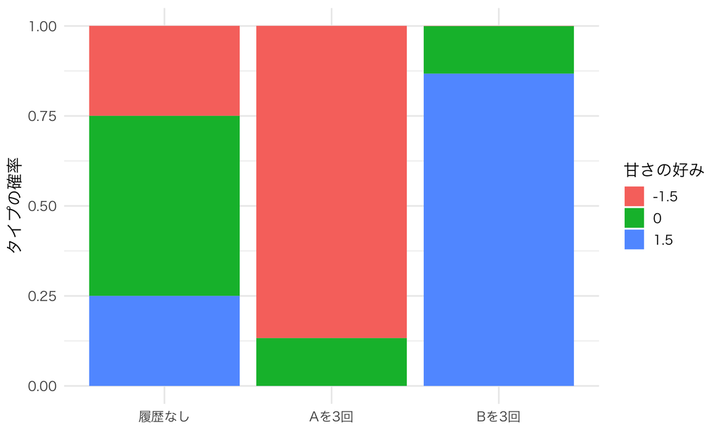

同じ母集団分布から出発しても、本人の履歴によってタイプの重みが変わる。価格は両商品とも150円。

```r
w_example <- rbind(pi_true, post_AAA, post_BBB)
d_example <- data.frame(
  information = factor(rep(c("履歴なし", "Aを3回", "Bを3回"), each = 3),
                       levels = c("履歴なし", "Aを3回", "Bを3回")),
  type = factor(rep(theta_grid, 3)), weight = as.vector(t(w_example)))
ggplot(d_example, aes(information, weight, fill = type)) +
  geom_col() + labs(x = NULL, y = "タイプの確率", fill = "甘さの好み")
```

本人の履歴が一件もなければ、空の積を $L(\vartheta_k;\varnothing)=1$ と定義するので、事後確率は $\pi_k$ のままである。また、履歴が増えても、観測のたびに真のタイプの重みが必ず増えるわけではないということにも注意したい。偶然の選択もあるためだ。真のタイプでも、たまたまそのタイプらしくない選択をすることがある。

## 3. 母集団の割合も未知なら：経験ベイズと個人別推定

### 3.1 何が既知で、何を推定するのか

ここからは、候補値 $\vartheta=(-1.5,0,1.5)$ だけを既知とし、割合 $\pi$ は未知とする。本人のタイプも観測されない。全員の履歴から母集団割合を推定し、その推定値を使って一人ずつ分布を更新する。

この仕組みを確かめるため、400人を16機会観測するデータを作る。まず、各人のタイプを一度だけ抽選する。生成する側は真の割合を知っているが、推定する側には渡さない。

```r
set.seed(202606)
N <- 400
Tmax <- 16
type_true <- sample(1:3, N, replace = TRUE, prob = pi_true)
theta_truth <- theta_grid[type_true]
```

次に、機会ごとの共通価格を100〜250円から独立に生成する。個人のタイプにも選択ショックにも依存しない価格なので、この実験には価格内生性を入れていない。

```r
prices <- data.frame(occasion = seq_len(Tmax),
                     pA = runif(Tmax, 1, 2.5), pB = runif(Tmax, 1, 2.5))
head(prices)
```

```
  occasion       pA       pB
1        1 1.421101 1.253396
2        2 1.776243 1.748683
3        3 1.928818 1.578342
4        4 1.025585 1.104145
5        5 2.250904 1.507847
6        6 1.901176 1.675559
```

一行を一人・一機会とし、同じ人には同じ係数、同じ機会には同じ価格を割り当てる。logit確率を計算してから、一様乱数 $U_{it}$ が「買わない」の確率までなら0、そこからAの確率を足したところまでならA、残りならBを選ばせる。これはGumbelショックを引いて効用を最大化する方法と同じ選択分布を生成する。

```r
id <- rep(seq_len(N), each = Tmax)
occasion <- rep(seq_len(Tmax), times = N)
pA <- prices$pA[occasion]; pB <- prices$pB[occasion]
prob <- choice_prob(theta_truth[id], pA, pB)
u <- runif(N * Tmax)
y <- as.integer(u > prob[, 1]) + as.integer(u > prob[, 1] + prob[, 2])
panel <- data.frame(id, occasion, pA, pB, y)  # 0=買わない、1=A、2=B
head(panel)
```

```
  id occasion       pA       pB y
1  1        1 1.421101 1.253396 2
2  1        2 1.776243 1.748683 2
3  1        3 1.928818 1.578342 2
4  1        4 1.025585 1.104145 2
5  1        5 2.250904 1.507847 2
6  1        6 1.901176 1.675559 2
```

分析者が観測するのは `panel` だけである。`theta_truth` は推定に使わず、答え合わせに使う。まず最初の4機会だけを観測した状況を考え、後で16機会まで増やす。

生成された選択割合も確認しよう。タイプ $k$ の人数を $N_k$ とすると、図の棒は

$$\widehat s_{jk}
=\frac{\sum_{i=1}^N\mathbf 1\{\theta_i=\vartheta_k\}
\sum_{t=1}^{16}\mathbf 1\{y_{it}=j\}}{16N_k}$$

である。分母はそのタイプの全選択機会数、分子はそのうち $j$ を選んだ回数だ。この確認だけは生成時のタイプを使う。

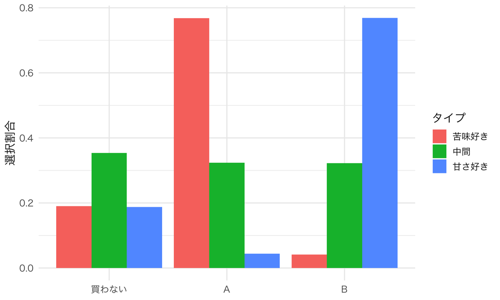

タイプ別の選択割合。分母はタイプ別人数×16機会であり、非購入も含む。

```r
choice_summary <- panel |>
  mutate(type = factor(type_true[id], labels = c("苦味好き", "中間", "甘さ好き")),
         product = factor(y, levels = 0:2, labels = c("買わない", "A", "B"))) |>
  count(type, product) |> group_by(type) |> mutate(share = n / sum(n))
ggplot(choice_summary, aes(product, share, fill = type)) +
  geom_col(position = "dodge") + labs(x = NULL, y = "選択割合", fill = "タイプ")
```

### 3.2 全員の履歴から母集団割合を推定する

一人のタイプが見えないので、本人の履歴の確率をタイプについて平均する。全員の履歴を $\mathcal H=(H_1,\ldots,H_N)$ と書くと、

$$M(\pi;H_i)=\sum_{k=1}^3\pi_k L(\vartheta_k;H_i),
\qquad
\ell(\pi;\mathcal H)=\sum_{i=1}^N\log M(\pi;H_i).$$

価格列に条件づけると顧客間でタイプとショックが独立なので、対数尤度を足し合わせられる。タイプを平均して取り除いたものを**周辺尤度**と呼ぶ。最尤推定は、$\pi_k\geq0,\sum_k\pi_k=1$ の制約のもとでこれを最大にする。

順序が重要である。**本人のタイプを固定して各回の確率を掛け、その後にタイプについて平均する。** 各回で先にタイプを平均してから掛ける $\prod_t\sum_k\pi_kP_{y_{it},t}(\vartheta_k)$ は、毎回タイプを引き直す別のモデルになる。

ここからは、上の数式を3段階に分けて計算する。まず $L(\vartheta_k;H_i)$ を個人・候補値ごとに求め、次に割合 $\pi$ を与えて $M(\pi;H_i)$ と全員分の対数尤度 $\ell(\pi;\mathcal H)$ を計算し、最後にその値が最大になる $\pi$ を探す。

**ステップ1：各人の履歴を、3つの候補値それぞれで評価する。**

個人 $i$ がタイプ $k$ だったと仮定すると、その人の履歴の対数尤度は

$$\ell_{ik}\equiv\log L(\vartheta_k;H_i)
=\sum_{t=1}^{T_i}\log P_{y_{it},t}(\vartheta_k)$$

である。ここで $\ell_{ik}$ は「一人・一候補値」の対数尤度で、全員分をまとめた $\ell(\pi;\mathcal H)$ とは区別する。対数を使うと、履歴の確率の積を足し算で計算でき、小さな確率を何度も掛けることによる数値的な問題を避けられる。

次の `panel_loglik()` は、この $\ell_{ik}$ を計算する関数である。`grid` に入っている候補値を一つ取り出して `th` とし、次の順で計算する。

1. `pr <- choice_prob(...)` で、データの各行について「買わない・A・B」の3つの確率を求める。この段階では、一行は一人の一機会であり、まだ履歴全体の確率ではない。
2. `chosen_prob` に、その行で**実際に選んだ選択肢の確率** $P_{y_{it},t}(\vartheta_k)$ だけを取り出す。`dat$y` は0・1・2、`pr` の列番号は1・2・3なので、列を選ぶときに `dat$y + 1` とする。`cbind()` は「データの行番号と、選択した商品の列番号」の組を作る。
3. `log_chosen_prob` で対数を取り、`rowsum(..., dat$id)` で同じ個人の機会を足し合わせる。これが $\ell_{ik}$ である。
4. `sapply()` で候補値を $-1.5,0,1.5$ と変えて同じ計算を繰り返し、結果を3列に並べる。

```r
panel_loglik <- function(dat, grid) {
  sapply(grid, function(th) {
    pr <- choice_prob(th, dat$pA, dat$pB)
    chosen_prob <- pr[cbind(seq_len(nrow(dat)), dat$y + 1)]
    log_chosen_prob <- log(chosen_prob)
    drop(rowsum(log_chosen_prob, dat$id))
  })
}
train4 <- subset(panel, occasion <= 4)
ell4 <- panel_loglik(train4, theta_grid)
knitr::kable(data.frame(customer = 1:6, ell4[1:6, ]), digits = 3,
             col.names = c("顧客 i", "候補値 −1.5", "候補値 0", "候補値 1.5"))
```

| 顧客 i | 候補値 −1.5 | 候補値 0 | 候補値 1.5 |
| --- | --- | --- | --- |
| 1 | -12.580 | -4.184 | -0.914 |
| 2 | -9.608 | -4.212 | -3.942 |
| 3 | -3.342 | -3.946 | -9.676 |
| 4 | -3.022 | -5.126 | -12.356 |
| 5 | -12.580 | -4.184 | -0.914 |
| 6 | -8.474 | -4.578 | -5.808 |

`train4` は各人の最初の4機会だけを取り出したデータである。`ell4` は400行×3列の表になり、上には最初の6人を表示した。**第 $i$ 行・第 $k$ 列の数値 `ell4[i, k]` が $\ell_{ik}$** に対応する。3つの列は、同じ人の同じ履歴を、3通りのタイプの仮定で評価した結果である。本人の真のタイプが分かっていなくても、どの列も計算できる。

例えば、`ell4[1, 2]` は「顧客1の好みが第2候補 $\vartheta_2=0$ だとしたら、その人の最初の4回の履歴はどれくらい起こりやすいか」を対数で表した値で、

$$\ell_{12}=\log L(0;H_1)
=\log P_{y_{11},1}(0)+\log P_{y_{12},2}(0)
+\log P_{y_{13},3}(0)+\log P_{y_{14},4}(0)$$

を計算している。このデータでは -4.184 となる。これは「顧客1が中間タイプである確率」ではなく、**中間タイプを仮定したときの履歴の対数尤度**である。

**ステップ2：割合を仮に与え、一人ずつの周辺尤度と全員分の対数尤度を計算する。**

ステップ1の表を使うと、割合 $\pi$ のもとでの一人の周辺尤度は

$$M(\pi;H_i)=\sum_{k=1}^3\pi_k\exp(\ell_{ik})$$

となる。さらに、その対数を400人分足せば $\ell(\pi;\mathcal H)$ が得られる。ここではまだ最適な割合を探さず、与えられた割合を評価するだけだ。

**まず、式をそのままコードにすると何が困るのか。** 一人分の3つの対数尤度を `ell_one`、仮の割合を `pi_try` とすれば、求めたい対数周辺尤度は `log(sum(pi_try * exp(ell_one)))` である。数式としては正しい。しかし、長い購入履歴では「その列が丸ごと起こる確率」は非常に小さくなりうる。ステップ1で対数を取って計算できていても、ここで `exp()` によって小さな確率に戻すと、コンピュータが表せる範囲を下回ることがある。

失敗を確かめるため、一人の長い履歴から $(-1000,-1001,-1002)$ という対数尤度が得られた場合を考えよう。これは計算上の問題を見せるための例であり、先ほどの4機会の `ell4` がこの値になっているわけではない。割合は3タイプとも $1/3$ と仮に置く。

```r
ell_one <- c(-1000, -1001, -1002)
pi_try <- rep(1 / 3, 3)
exp(ell_one)                       # タイプごとの履歴の確率に戻す
```

```
[1] 0 0 0
```

```r
marginal_naive <- sum(pi_try * exp(ell_one))
marginal_naive                     # 周辺尤度
```

```
[1] 0
```

```r
log(marginal_naive)                # その対数
```

```
[1] -Inf
```

```r
pi_try * exp(ell_one) / marginal_naive  # ベイズの公式も計算してみる
```

```
[1] NaN NaN NaN
```

本当は $\exp(-1000)>0$ だが、Rの通常の数値計算では小さすぎて0になる。このように、小さすぎる数を表せなくなる問題を**アンダーフロー（underflow）**という。上のコードでは、3つの確率がすべて0になり、周辺尤度も0、対数は `-Inf` になってしまった。事後確率も $0/0$ なので `NaN`（数値として計算できない）になる。**最後に対数を取っても、その前に0になって失われた情報は戻らない。** この値を最適化に渡しても、どの割合が履歴によく合うかを比較できない。

**そこで、log-sum-exp trickを使う。** これは、指数を取って足したものの対数を、極端に小さな数を直接作らずに計算する工夫である。新しい推定方法ではなく、同じ対数尤度を計算するための式の変形だ。

まず一人に注目したまま、割合と履歴の確率をまとめる。$\pi_k\exp(\ell_{ik})$ の対数を

$$z_{ik}=\log\pi_k+\ell_{ik}$$

と置けば、求めたいのは $\log M(\pi;H_i)=\log\sum_k\exp(z_{ik})$ である。ここで初めて、3つの $z_{ik}$ のうち最大の値を $m_i=\max_k z_{ik}$ と置く。すべての $z_{ik}$ からこの最大値を引くと、最大のものは0、残りは0以下になる。したがって、指数を取ったとき、最大の項は必ず $\exp(0)=1$ となり、和が0になる問題を避けられる。

同じ数値例で、最大値を引くところまで計算しよう。

```r
z_one <- log(pi_try) + ell_one
m_one <- max(z_one)
shifted_one <- exp(z_one - m_one)
knitr::kable(data.frame(type = 1:3, z = z_one,
                        shifted = z_one - m_one, exponential = shifted_one),
             digits = 6,
             col.names = c("タイプ", "割合を含めた対数 z", "最大値を引いた z − m", "exp(z − m)"))
```

| タイプ | 割合を含めた対数 z | 最大値を引いた z − m | exp(z − m) |
| --- | --- | --- | --- |
| 1 | -1001.099 | 0 | 1.000000 |
| 2 | -1002.099 | -1 | 0.367879 |
| 3 | -1003.099 | -2 | 0.135335 |

もともとの値は約 $(-1001.099,-1002.099,-1003.099)$ だったが、最大値を引くと $(0,-1,-2)$ になった。その指数は約 $(1,0.368,0.135)$ なので、今度は足し算ができる。

ただし、最大値を引いたままでは元の対数尤度ではない。どこで元に戻すのかが大切だ。指数の共通因子 $\exp(m_i)$ をくくり出すと、

$$\begin{aligned}
\log\sum_k\exp(z_{ik})
&=\log\left\{\exp(m_i)\sum_k\exp(z_{ik}-m_i)\right\}\\
&=m_i+\log\sum_k\exp(z_{ik}-m_i).
\end{aligned}$$

つまり、**最大値を引いてから指数を取り、和の対数を取った後で、最大値を足し戻す。** コードでは最後の行だけを計算し、$\exp(m_i)$ 自体は作らない。これがlog-sum-exp trickである。

```r
log_marginal_stable <- m_one + log(sum(shifted_one))
log_marginal_stable
```

```
[1] -1000.691
```

結果は約 -1000.691006 となる。元の周辺尤度はコンピュータで直接表すには小さすぎても、**その対数なら有限の値として計算できる**。最適化で必要なのはこちらであり、小さな周辺尤度そのものに戻す必要はない。

**事後確率も、同じ計算から求められる。** ベイズの公式の分子と分母に共通する $\exp(m_i)$ を約分すれば、

$$w_{ik}(\pi;H_i)
=\frac{\exp(z_{ik})}{\sum_\ell\exp(z_{i\ell})}
=\frac{\exp(z_{ik}-m_i)}{\sum_\ell\exp(z_{i\ell}-m_i)}$$

となる。こちらは「同じ数で割ったものどうしの比」なので、最大値を足し戻す操作は要らない。

```r
weights_stable <- shifted_one / sum(shifted_one)
knitr::kable(data.frame(type = 1:3, prior = pi_try, posterior = weights_stable),
             digits = 6, col.names = c("タイプ", "仮の割合", "履歴を見た後の事後確率"))
```

| タイプ | 仮の割合 | 履歴を見た後の事後確率 |
| --- | --- | --- |
| 1 | 0.333333 | 0.665241 |
| 2 | 0.333333 | 0.244728 |
| 3 | 0.333333 | 0.090031 |

素朴なコードでは3タイプとも `NaN` だったが、今度は約 $(0.665,0.245,0.090)$ と計算できた。どのタイプのもとでも長い履歴全体の確率は非常に小さいが、タイプ間の相対的な起こりやすさは比較できるのである。

**最後に、全員分を計算する関数にまとめる。** `mixture_eval(ell, pi)` に渡す `ell` はステップ1の400行×3列の表、`pi` は仮に与えた3つの割合である。今の一人分の計算を各行に行い、対数周辺尤度を400人分足せばよい。

以下の `z` は各列に $\log\pi_k$ を加えた表、`rowmax` は一人ごとの最大値である。`e` に最大値を引いてから指数を取った値を入れ、`totals` にその行ごとの和を入れる。返す `loglik` は全員分を足した対数尤度、`weights` は個人ごとの事後確率の表になる。

```r
mixture_eval <- function(ell, pi) {
  z <- sweep(ell, 2, log(pi), "+")
  rowmax <- apply(z, 1, max)
  e <- exp(z - rowmax)
  totals <- rowSums(e)
  list(weights = e / totals, loglik = sum(rowmax + log(totals)))
}
```

`sweep(..., 2, ...)` は列ごとに割合の対数を加える操作、`apply(..., 1, max)` は行ごとに最大値を取る操作である。`e / totals` では各人の行をその行の合計で割る。短い履歴でも長い履歴でも同じ関数を使えるので、ここから先はこの形で計算する。

**ステップ3：全員分の対数尤度が最大になる割合を探す。**

求めたいのは、$\ell(\pi;\mathcal H)$ を最大にする $\widehat\pi$ である。候補値と履歴が同じなら `ell4` の中身は変わらないので、**`ell4` を固定したまま、`pi` だけを変えて `loglik` を比べる**。

割合が正で合計1になるよう、自由に動かす数を $a_1,a_2$ の2つにし、$a_3=0$ として

$$\pi_k(a)=\frac{e^{a_k}}{e^{a_1}+e^{a_2}+1},\qquad k=1,2,3$$

と変換する。コードの `softmax()` がこの変換に対応する。$a_1=a_2=0$ から始めると、最初の割合は $(1/3,1/3,1/3)$ になる。$a$ は計算のための変数で、新しい好みの係数ではない。この変換は正の割合を表し、0の割合には極限として近づける。

`optim()` は関数を最小にするので、`-mixture_eval(...)$loglik`、すなわち**全員分の対数尤度にマイナスを付けた値**を渡す。$a$ の候補を割合に変換して対数尤度を計算することを繰り返し、最終的な割合を `pi` として返す。

```r
fit_known_pi <- function(ell) {
  softmax <- function(a) { z <- c(a, 0); z <- exp(z - max(z)); z / sum(z) }
  opt <- optim(rep(0, ncol(ell) - 1),
               function(a) -mixture_eval(ell, softmax(a))$loglik,
               method = "BFGS", control = list(reltol = 1e-11, maxit = 1000))
  if (opt$convergence != 0) stop("Known-support MLE did not converge")
  pi <- softmax(opt$par)
  c(list(pi = pi), mixture_eval(ell, pi))
}
fit4 <- fit_known_pi(ell4)
knitr::kable(data.frame(theta = theta_grid, truth = pi_true, estimate = fit4$pi),
             digits = 3, col.names = c("候補値", "真の割合", "4機会から推定した割合"))
```

| 候補値 | 真の割合 | 4機会から推定した割合 |
| --- | --- | --- |
| -1.5 | 0.25 | 0.261 |
| 0.0 | 0.50 | 0.470 |
| 1.5 | 0.25 | 0.269 |

結果の `fit4$pi` が $\widehat\pi$、`fit4$loglik` が $\ell(\widehat\pi;\mathcal H)$、`fit4$weights[i, k]` が推定した割合を使った事後確率 $w_{ik}(\widehat\pi;H_i)$ である。最後の値を本人の好みの推測に使うのが、次節の経験ベイズである。

ここで未知の母集団パラメータは割合だけだ。真の候補値と共通係数が分かっているという簡略化のもとで推定している。表の `pi_true` は結果との比較に使うだけで、`fit_known_pi()` には渡していない。真値との差には、400人を抽選した偶然と、各人の4回の選択の偶然が含まれる。

### 3.3 推定した分布で本人を更新する：経験ベイズ

推定した $\widehat\pi$ を事前確率として使い、ベイズ更新の式に代入することを考える。

$$\widehat w_{ik}\equiv
\frac{\widehat\pi_k L(\vartheta_k;H_i)}
{\sum_\ell\widehat\pi_\ell L(\vartheta_\ell;H_i)}.$$

母集団分布をデータから推定し、それを本人の履歴と組み合わせる手続きが**経験ベイズ（empirical Bayes）**である。`fit4$weights` にこの計算結果が入っている。前節のベイズ更新と式の形は同じだが、今回は母集団割合が推定値になっている。その推定誤差は、この重みだけでは全面的には反映していない。

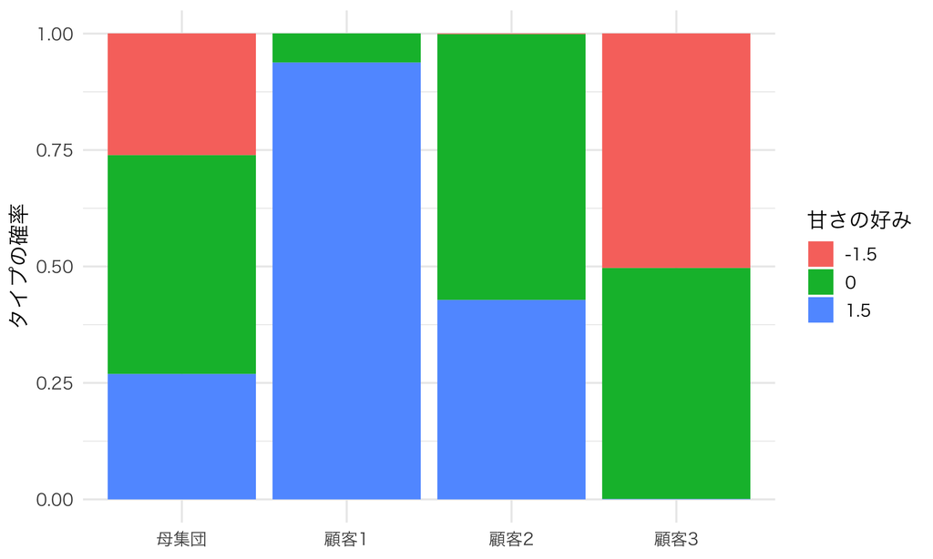

同じ母集団割合から出発しても、顧客ごとの4回の履歴で事後の重みが変わる。

```r
show_ids <- c(1, 2, 3)
w_show <- rbind(fit4$pi, fit4$weights[show_ids, ])
weights_plot <- data.frame(
  information = factor(rep(c("母集団", paste0("顧客", show_ids)), each = 3),
                       levels = c("母集団", paste0("顧客", show_ids))),
  type = factor(rep(theta_grid, 4)), weight = as.vector(t(w_show)))
ggplot(weights_plot, aes(information, weight, fill = type)) +
  geom_col() + labs(x = NULL, y = "タイプの確率", fill = "甘さの好み")
```

この図に出てくる顧客1〜3について、データ生成時に割り当てた**本当のタイプ（正解）**も確認しよう。次の表は、その値と、図の3色に対応する事後確率を並べたものである。

```r
type_labels <- c("苦味好き", "中間", "甘さ好き")
truth_check <- data.frame(
  customer = show_ids,
  true_theta = theta_truth[show_ids],
  true_type = type_labels[type_true[show_ids]],
  fit4$weights[show_ids, ])
knitr::kable(truth_check, digits = 3, row.names = FALSE,
             col.names = c("顧客", "真の θ", "本当のタイプ",
                           "苦味好きの確率", "中間の確率", "甘さ好きの確率"))
```

| 顧客 | 真の θ | 本当のタイプ | 苦味好きの確率 | 中間の確率 | 甘さ好きの確率 |
| --- | --- | --- | --- | --- | --- |
| 1 | 1.5 | 甘さ好き | 0.000 | 0.062 | 0.938 |
| 2 | 0.0 | 中間 | 0.001 | 0.570 | 0.428 |
| 3 | 0.0 | 中間 | 0.503 | 0.496 | 0.001 |

「正解」が分かるのは、今回は自分でタイプを抽選してデータを作ったからである。この答え合わせでは生成時に保存した `theta_truth` と `type_true` を参照しているが、母集団割合や事後確率の推定には渡していない。4回の履歴を使っても、本当のタイプの確率が1になるとは限らない。表の正解と事後確率を比べ、どの顧客についてタイプを絞り込めているかを確認しよう。

### 3.4 一人ずつ推定すればよいのではないか

本人の尤度だけを最大にすることもできる。候補値を変えず、

$$\widehat k_i^{\mathrm{NP}}\in\arg\max_{k\in\{1,2,3\}}L(\vartheta_k;H_i),
\qquad \widehat\theta_i^{\mathrm{NP}}=\vartheta_{\widehat k_i^{\mathrm{NP}}}$$

とするのが、この例での**個人別推定（no pooling）**である。他人のデータも母集団割合も使わない。有限個の候補なので最大値は存在するが、短い履歴から一つのタイプを選ぶ結果は偶然に左右されるというのが難点である。同点なら、以下のコードでは番号の小さい候補を選ぶ。

| 方法 | 本人について出す答え | 集団の情報の使い方 |
| --- | --- | --- |
| 母集団の分布のみ | 全員に同じ $\widehat\pi$ | 本人向けには更新しない |
| 個人別最尤 | 尤度が最大のタイプ一つ | 使わない |
| 経験ベイズ | 本人の履歴に応じた $\widehat w_i$ | 母集団分布を本人の尤度で更新する |

では、この3つを評価しよう。ここでは、各方法で本人の好みを一つの数に要約し、真の係数との二乗誤差を比べる。経験ベイズでは、3タイプの事後確率で平均した**事後平均**

$$\widehat\theta_i^{\mathrm{EB}}=\sum_{k=1}^3\widehat w_{ik}\vartheta_k$$

を使う。

個人別最尤は一つのタイプを選ぶ方法なので、平均という形で書くなら、**選んだタイプに重み1、残りに重み0**を置く。

$$\widehat w_{ik}^{\mathrm{NP}}
=\mathbf 1\{k=\widehat k_i^{\mathrm{NP}}\},\qquad
\widehat\theta_i^{\mathrm{NP}}
=\sum_{k=1}^3\widehat w_{ik}^{\mathrm{NP}}\vartheta_k
=\vartheta_{\widehat k_i^{\mathrm{NP}}}.$$

この「平均」は、選ばれた候補値そのものになる。例えば $-1.5$ を選んだなら、$1\times(-1.5)+0\times0+0\times1.5=-1.5$ である。重み1は、推定結果を点分布として表すための記法であり、「そのタイプである事後確率が100%」という意味ではない。

母集団の分布だけを使う方法では、全員に共通の平均

$$\widehat\theta_i^{\mathrm{POP}}
=\sum_{k=1}^3\widehat\pi_k\vartheta_k$$

を使う。以上の3つは、同じ候補値をどの重みで平均するかが異なる。経験ベイズと母集団平均は候補値の間の値を取ることもあるが、それは分布の要約であり、新たなタイプを追加したわけではない。

方法 $m\in\{\mathrm{POP},\mathrm{NP},\mathrm{EB}\}$ の評価指標を

$$\operatorname{RMSE}(m)=\sqrt{\frac1N\sum_i(\widehat\theta_i^m-\theta_i)^2}$$

と定義する。これは**平均二乗誤差の平方根（RMSE）**で、小さいほど真の係数に近い。以下の表は、同じ400人の最初の4機会から得た推定値を比較する。

```r
individual_mle <- function(ell, grid) {
  grid[max.col(ell, ties.method = "first")]
}
np4 <- individual_mle(ell4, theta_grid)
eb4 <- drop(fit4$weights %*% theta_grid)
knitr::kable(data.frame(method = c("母集団平均", "個人別最尤", "経験ベイズの事後平均"),
  rmse = c(sqrt(mean((sum(fit4$pi * theta_grid) - theta_truth)^2)),
           sqrt(mean((np4 - theta_truth)^2)), sqrt(mean((eb4 - theta_truth)^2)))),
  digits = 3, col.names = c("好みの要約", "真の係数とのRMSE"))
```

| 好みの要約 | 真の係数とのRMSE |
| --- | --- |
| 母集団平均 | 1.102 |
| 個人別最尤 | 0.671 |
| 経験ベイズの事後平均 | 0.542 |

このデータでは、経験ベイズの事後平均のRMSEが最も小さい。母集団の情報を使いながら一つのタイプに決めず平均することで、短い履歴の偶然に左右される影響を抑えている。ただし、これは一回のデータでの比較であり、どの標本でも必ず同じ順位になるという意味ではない。

一方で、個人別推定には、対象と違う集団の情報に引っ張られない利点がある。経験ベイズは、本人の情報が少なくても他の人の情報を使える一方、全員に同じ母集団分布を使ってよいかが重要になる。履歴が豊富でタイプ間の尤度に大きな差があれば、本人の情報が強くなる。

**ノート数学コラム：事後平均の最適性と経験ベイズの限界**

**正しい母集団分布が分かっている場合、事後平均には二乗誤差を最小にする性質がある。** その性質と、実際に母集団分布を推定して使う経験ベイズの成績は分けて考えよう。

まず、価格列を所与とし、モデルが正しく、真の母集団割合 $\pi^0$ が既知だとする。全員の履歴 $\mathcal H$ のもとでの事後平均を

$$m_i^*=E[\theta_i\mid\mathcal H]
=E[\theta_i\mid H_i]
=\sum_{k=1}^3w_{ik}(\pi^0;H_i)\vartheta_k$$

と書く。2つ目の等号は、母集団割合が既知なら、他人の履歴は本人のタイプについて追加の情報を持たないという、このモデルの個人間独立性による。

全履歴から作る任意の推定値 $a_i=a_i(\mathcal H)$ に対して、

$$E[(a_i-\theta_i)^2\mid\mathcal H]
=\operatorname{Var}(\theta_i\mid\mathcal H)+(a_i-m_i^*)^2$$

が成り立つ。$a_i-\theta_i=(a_i-m_i^*)+(m_i^*-\theta_i)$ を二乗して期待値を取ると、交差項が0になるからである。第1項は $a_i$ に依存せず、第2項は $a_i=m_i^*$ で0になる。したがって、正しい事後平均は、データを見た後の期待二乗誤差を最小にする。[UC Berkeley Stat 210A「Bayes Estimation」§2](https://stat210a.berkeley.edu/fall-2025/reader/bayes-estimation.html#bayes-estimator)

タイプと履歴の両方について平均したリスクを $R(a_i)=E[(a_i-\theta_i)^2]$ とすると、さらに

$$R(a_i)-R(m_i^*)=E[(a_i-m_i^*)^2]\geq0$$

となる。この式は、正しい事後平均からどれだけ離れるかが、平均的な二乗誤差の増加になることを示す。経験ベイズでは $\pi^0$ を $\widehat\pi$ に置き換えるため、その推定誤差によって $\widehat\theta_i^{\mathrm{EB}}$ と $m_i^*$ はずれ得る。よって、**この最適性だけから、経験ベイズが有限標本で必ず個人別最尤より良いとは言えない。** また、ここで平均しているのは母集団から抽選されるタイプと履歴であり、各人の真のタイプを固定した場合の優位性や、一回の標本でのRMSEの順位を保証するものでもない。

### 3.5 履歴を長くすると何が変わるか

観測する機会を1・2・4・8・16と増やすたび、全員の履歴から母集団割合を推定し直す。そのうえで、同じ顧客1の重みがどう変わるかを確認する。選好そのものが変化するのではなく、利用できる履歴が増える実験だ。

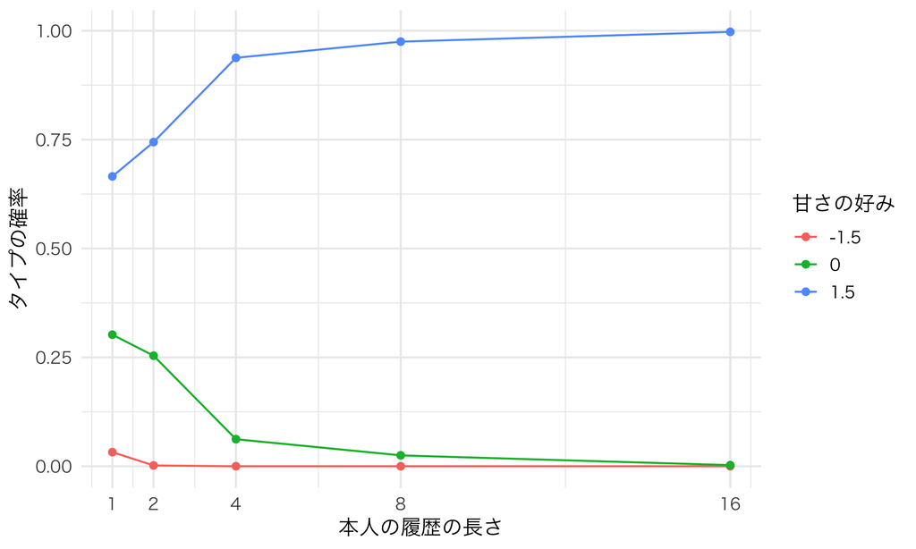

観測履歴が増えたときの、同じ顧客1についてのタイプの重み。真のタイプは推定に使わない。

```r
history_weights <- do.call(rbind, lapply(c(1, 2, 4, 8, 16), function(h) {
  ell_h <- panel_loglik(subset(panel, occasion <= h), theta_grid)
  fit_h <- fit_known_pi(ell_h)
  data.frame(history = h, type = factor(theta_grid), weight = fit_h$weights[1, ])
}))
ggplot(history_weights, aes(history, weight, color = type)) +
  geom_line() + geom_point() + scale_x_continuous(breaks = c(1, 2, 4, 8, 16)) +
  labs(x = "本人の履歴の長さ", y = "タイプの確率", color = "甘さの好み")
```

生成時の顧客1の好みは 1.5 である。この例では何回の観測でどれくらい分かったかを図から読もう。全員の人数 $N$ を増やして母集団分布を詳しく知ることと、本人の観測回数 $T_i$ を増やすことは違う。$N$ が非常に大きくても、本人の履歴が1回なら、その人については曖昧さが残り得る。

**ノートビジネスの現場で：どの顧客どうしで情報を共有するか**

同じ商品を扱っていても、店舗・地域・契約プランによって顧客層が違うことがある。全員を一つの母集団から来た人として扱うと、情報の少ない顧客ほど、対象に合わない分布へ引き寄せられるかもしれない。観測属性に応じて母集団分布を変えることもできるが、その場合は各集団の人数も問題になる。個人の履歴を使うことと、集団をどう定義するかは、両方とも考える必要がある。

## 4. タイプの値と割合を同時に推定する

### 4.1 候補値を固定していた仮定を緩める

これまでは苦味好きの係数がちょうど $-1.5$ であると知っていた。実際には、その値も分からないことが普通だ。そこで、タイプ数 $K=3$ は既知のまま、候補値 $\vartheta_1,\vartheta_2,\vartheta_3$ と割合 $\pi$ を同時に推定する。未知の母集団パラメータは $\eta=(\pi,\vartheta)$ になる。

$$\ell(\pi,\vartheta;\mathcal H)
=\sum_{i=1}^N\log\left[\sum_{k=1}^3\pi_kL(\vartheta_k;H_i)\right].$$

推定するのは、**全員に共通するタイプの候補値と割合**である。一人につき自由な係数を一つ推定する話ではない。混合分布の番号を入れ替えても同じモデルなので、$\vartheta_1<\vartheta_2<\vartheta_3$ の順に並べて名前を付ける。

ここでは16機会をすべて使う。母集団分布を推定した後の本人の重みは、

$$\widehat w_{ik}=
\frac{\widehat\pi_k L(\widehat\vartheta_k;H_i)}
{\sum_\ell\widehat\pi_\ell L(\widehat\vartheta_\ell;H_i)}$$

となる。候補値が推定値になっただけで、本人の履歴を取り込む式の構造は同じだ。

### 4.2 最尤推定の計算を、所属の推測から考える

推定するパラメータは増えたが、目的は引き続き、観測データの対数尤度を最大にすることである。

$$(\widehat\pi,\widehat\vartheta)
\in\arg\max_{\pi,\vartheta}\ell(\pi,\vartheta;\mathcal H).$$

**この対数尤度を、そのまま直接最適化してよい。** 割合の合計1という制約を3.2と同じ変数変換で満たせば、`optim()` などで割合と候補値をまとめて動かせる。今回は候補値が3個、割合の自由度が2個なので、実質5個のパラメータであり、直接最適化でも十分扱える。

ただし、このモデルには計算を簡単にできそうな構造がある。**もし誰がどのタイプか分かっていれば、割合はタイプ別の人数から求まり、候補値はそのタイプの人の履歴だけで推定できる。** 全員のデータを使って一度に解く問題を、人数を数える計算と、タイプごとの推定に分けられるわけだ。難しいのは、その所属が見えないことである。

そこで、所属そのものの代わりに、**所属確率を使えないだろうか。** 候補値と割合を仮に置けば、前節のベイズ更新で各人の所属確率を計算できる。その確率を「人数の端数」や「推定の重み」として使い、候補値と割合を更新してみる。こうして得た値は、元の対数尤度を大きくするだろうか。まず同じコーヒーのデータで、この計算を2回繰り返して確かめよう。

### 4.3 計算の出発点：仮の分布を置く

所属確率を求めるには、それを計算するための候補値と割合が必要だ。そこで、まず仮の値を置くところから始める。

使うのは、3.1で作った400人・各16機会の `panel` である。初期値を

$$\vartheta^{(0)}=(-2,0,2),\qquad
\pi^{(0)}=(1/3,1/3,1/3)$$

とする。上付きの $(0)$ は「まだ一度も更新していない」という意味で、選択機会の番号ではない。これは計算の出発点であり、真の値を知っているという仮定ではない。生成時の正解 `theta_truth` や `pi_true` は使わない。

```r
demo_theta0 <- c(-2, 0, 2)
demo_pi0 <- rep(1 / 3, 3)
demo_ell0 <- panel_loglik(panel, demo_theta0)
knitr::kable(data.frame(type = 1:3, theta = demo_theta0, pi = demo_pi0),
             digits = 3, col.names = c("タイプ k", "仮の候補値", "仮の割合"))
```

| タイプ k | 仮の候補値 | 仮の割合 |
| --- | --- | --- |
| 1 | -2 | 0.333 |
| 2 | 0 | 0.333 |
| 3 | 2 | 0.333 |

`demo_ell0[i, k]` は、この仮の候補値で計算した $\log L(\vartheta_k^{(0)};H_i)$ である。3.2では候補値を固定して割合だけを動かしたが、ここからは候補値も動かす。

### 4.4 1回目の更新を順番に計算する

**計算A：今の候補値と割合なら、各人はどのタイプらしいか。**

最初に使うのは、すでに学んだベイズの公式である。初期値のもとでの所属確率は

$$w_{ik}^{(0)}=
\frac{\pi_k^{(0)}L(\vartheta_k^{(0)};H_i)}
{\sum_{\ell=1}^3\pi_\ell^{(0)}L(\vartheta_\ell^{(0)};H_i)}.$$

同じ履歴を3つの候補値で評価し、仮の割合を掛け、合計で割る。ここでは、所属に迷いが残る例として顧客252を詳しく見る。次の表の「割合×尤度」が分子であり、その3行の合計が分母になる。

```r
demo0 <- mixture_eval(demo_ell0, demo_pi0)
demo_w0 <- demo0$weights
demo_id <- 252
demo_lik0 <- exp(demo_ell0[demo_id, ])
demo_joint0 <- demo_pi0 * demo_lik0
knitr::kable(data.frame(
  type = 1:3, theta = demo_theta0,
  likelihood = formatC(demo_lik0, format = "e", digits = 3),
  joint = formatC(demo_joint0, format = "e", digits = 3),
  weight = demo_w0[demo_id, ]), digits = 4,
  col.names = c("タイプ k", "仮の候補値", "顧客252の尤度", "割合×尤度", "所属確率"))
```

| タイプ k | 仮の候補値 | 顧客252の尤度 | 割合×尤度 | 所属確率 |
| --- | --- | --- | --- | --- |
| 1 | -2 | 5.220e-08 | 1.740e-08 | 0.5729 |
| 2 | 0 | 3.891e-08 | 1.297e-08 | 0.4271 |
| 3 | 2 | 3.533e-22 | 1.178e-22 | 0.0000 |

```r
stopifnot(max(abs(demo_joint0 / sum(demo_joint0) -
                  demo_w0[demo_id, ])) < 1e-12)
```

表の `e-09` のような表記は $10^{-9}$ を掛けるという意味だ。16回分の確率の積なので尤度は小さくなるが、比を取った所属確率は普通の0〜1の数になる。実際の計算では `mixture_eval()` が対数を使ってこの比を安定して求めている。

顧客252は、タイプ1である確率が約 0.573、タイプ2である確率が約 0.427 となった。ここで大きい方に決めてしまわず、両方の可能性を残す。同じ計算を400人全員に行う。

```r
demo_ids <- c(1, 2, 3, 252)
knitr::kable(data.frame(customer = demo_ids,
                        demo_w0[demo_ids, ]), digits = 4, row.names = FALSE,
             col.names = c("顧客", "タイプ1の確率", "タイプ2の確率", "タイプ3の確率"))
```

| 顧客 | タイプ1の確率 | タイプ2の確率 | タイプ3の確率 |
| --- | --- | --- | --- |
| 1 | 0.0000 | 0.0034 | 0.9966 |
| 2 | 0.0000 | 1.0000 | 0.0000 |
| 3 | 0.0000 | 1.0000 | 0.0000 |
| 252 | 0.5729 | 0.4271 | 0.0000 |

行の合計は1である。表示上の0や1は丸めた値で、厳密な確率が必ず0や1になったという意味ではない。

**計算Bの前半：所属確率を人数として足し、母集団割合を更新する。**

もし所属が見えていれば、タイプ1の人を一人ずつ数え、その人数を400で割ればよい。所属が見えない今は、タイプ1である確率が0.573の人には0.573人分として参加してもらう。このように確率を足した

$$n_k^{(0)}=\sum_{i=1}^{400}w_{ik}^{(0)}$$

は、初期値と履歴のもとでの「タイプ $k$ の人数の期待値」である。実際の人数を観測したわけではないので、小数になってよい。この人数を使って

$$\pi_k^{(1)}=\frac{n_k^{(0)}}{400}$$

と更新する。

```r
demo_count0 <- colSums(demo_w0)
demo_pi1 <- demo_count0 / N
knitr::kable(data.frame(type = 1:3, expected_count = demo_count0,
                        old_pi = demo_pi0, new_pi = demo_pi1), digits = 4,
             col.names = c("タイプ k", "人数の期待値", "更新前の割合", "更新後の割合"))
```

| タイプ k | 人数の期待値 | 更新前の割合 | 更新後の割合 |
| --- | --- | --- | --- |
| 1 | 106.4057 | 0.3333 | 0.2660 |
| 2 | 191.7293 | 0.3333 | 0.4793 |
| 3 | 101.8650 | 0.3333 | 0.2547 |

例えばタイプ1の人数の期待値は約 106.406 人なので、更新後の割合は 106.406 / 400 = 約 0.266 となる。3タイプの人数の期待値は合計400、更新後の割合は合計1である。

**計算Bの後半：同じ所属確率を重みにして、好みの候補値を更新する。**

割合だけでなく、最初に $-2,0,2$ と置いた候補値も直したい。もしタイプ1の人が誰か分かっていれば、その人たちの履歴を使って、タイプ1の好みの値を最尤推定できる。ここでも0か1の所属の代わりに、計算Aで求めた確率を使う。

タイプ $k$ の候補値を $a$ にしたときの重み付き対数尤度を

$$G_k^{(0)}(a)=\sum_{i=1}^{400}w_{ik}^{(0)}\log L(a;H_i)$$

と書き、これが最大になる値に更新する。

$$\vartheta_k^{(1)}\in\arg\max_{a\in[-6,6]}G_k^{(0)}(a).$$

例えばタイプ1の計算では、顧客252の項は約 $0.573\log L(a;H_{252})$ となる。タイプ2の計算にも約 $0.427\log L(a;H_{252})$ として参加する。本人の好みの推定値を平均するのではなく、**本人の履歴の対数尤度に重みを付けて、全員分を足す**。

この最適値は、logitでは一般に単純な平均の式では求まらない。以下では `optimize()` で1タイプずつ数値的に求める。探索範囲 $[-6,6]$ は計算のために設定した区間で、候補値を最初の3つの値に固定する制約ではない。

```r
demo_theta1 <- vapply(1:3, function(k) {
  optimize(function(a) -sum(demo_w0[, k] * panel_loglik(panel, a)),
           interval = c(-6, 6), tol = 1e-8)$minimum
}, numeric(1))
knitr::kable(data.frame(type = 1:3, old_theta = demo_theta0,
                        new_theta = demo_theta1), digits = 4,
             col.names = c("タイプ k", "更新前の候補値", "更新後の候補値"))
```

| タイプ k | 更新前の候補値 | 更新後の候補値 |
| --- | --- | --- |
| 1 | -2 | -1.5559 |
| 2 | 0 | -0.0040 |
| 3 | 2 | 1.5335 |

`optimize()` は最小値を探すので、$G_k^{(0)}(a)$ にマイナスを付けて渡している。この間、`demo_w0` は固定する。割合を更新した直後に所属確率を計算し直すのではなく、**割合と候補値の両方を、同じ計算Aの重みで更新する**。これで1回目の更新 $(\pi^{(0)},\vartheta^{(0)})\to(\pi^{(1)},\vartheta^{(1)})$ が完了した。

### 4.5 2回目の更新：新しい分布で所属を計算し直す

候補値と割合が変わったので、同じ履歴でも所属確率が変わる。計算Aに戻り、今度は

$$w_{ik}^{(1)}=
\frac{\pi_k^{(1)}L(\vartheta_k^{(1)};H_i)}
{\sum_{\ell=1}^3\pi_\ell^{(1)}L(\vartheta_\ell^{(1)};H_i)}$$

を求める。本人の履歴が増えたわけではない。変わったのは、その履歴を評価するために使う母集団パラメータだ。

```r
demo_ell1 <- panel_loglik(panel, demo_theta1)
demo1 <- mixture_eval(demo_ell1, demo_pi1)
demo_w1 <- demo1$weights
knitr::kable(data.frame(type = 1:3,
                        weight0 = demo_w0[demo_id, ],
                        weight1 = demo_w1[demo_id, ]), digits = 4,
             col.names = c("タイプ k", "顧客252：初期値での確率", "顧客252：1回更新後の確率"))
```

| タイプ k | 顧客252：初期値での確率 | 顧客252：1回更新後の確率 |
| --- | --- | --- |
| 1 | 0.5729 | 0.841 |
| 2 | 0.4271 | 0.159 |
| 3 | 0.0000 | 0.000 |

顧客252のタイプ1の確率は約 0.573 から約 0.841 に変わった。更新後の候補値と割合のもとでは、この人の履歴はタイプ1に属すると説明しやすくなっている。

続いて計算Bを行う。新しい所属確率 $w_{ik}^{(1)}$ を固定して人数を数え直し、重み付き対数尤度も最大化し直す。

```r
demo_count1 <- colSums(demo_w1)
demo_pi2 <- demo_count1 / N
demo_theta2 <- vapply(1:3, function(k) {
  optimize(function(a) -sum(demo_w1[, k] * panel_loglik(panel, a)),
           interval = c(-6, 6), tol = 1e-8)$minimum
}, numeric(1))
knitr::kable(data.frame(type = 1:3, expected_count = demo_count1,
                        pi1 = demo_pi1, pi2 = demo_pi2,
                        theta1 = demo_theta1, theta2 = demo_theta2), digits = 4,
             col.names = c("タイプ k", "人数の期待値", "1回目の割合", "2回目の割合",
                           "1回目の候補値", "2回目の候補値"))
```

| タイプ k | 人数の期待値 | 1回目の割合 | 2回目の割合 | 1回目の候補値 | 2回目の候補値 |
| --- | --- | --- | --- | --- | --- |
| 1 | 110.7534 | 0.2660 | 0.2769 | -1.5559 | -1.5147 |
| 2 | 181.7459 | 0.4793 | 0.4544 | -0.0040 | -0.0093 |
| 3 | 107.5007 | 0.2547 | 0.2688 | 1.5335 | 1.4805 |

これで2回目の更新が終わった。候補値と割合が履歴にどれくらい合っているかを、4.1で書いた**観測データの対数尤度**で確かめよう。ここで計算するのは、タイプについて平均した履歴の確率の対数であり、更新に使った重み付き対数尤度とは異なる。

```r
demo2 <- mixture_eval(panel_loglik(panel, demo_theta2), demo_pi2)
demo_ll <- c(demo0$loglik, demo1$loglik, demo2$loglik)
knitr::kable(data.frame(stage = c("初期値", "1回目の更新後", "2回目の更新後"),
                        loglik = demo_ll), digits = 4,
             col.names = c("計算の段階", "観測データの対数尤度"))
```

| 計算の段階 | 観測データの対数尤度 |
| --- | --- |
| 初期値 | -5828.400 |
| 1回目の更新後 | -5722.206 |
| 2回目の更新後 | -5720.177 |

```r
stopifnot(all(diff(demo_ll) >= -1e-6),
          max(abs(rowSums(demo_w0) - 1)) < 1e-12,
          max(abs(rowSums(demo_w1) - 1)) < 1e-12,
          all(diff(demo_theta1) > 0), all(diff(demo_theta2) > 0))
```

対数尤度は大きくなった。まだ2回なので推定を終えるには早いが、「所属確率を求める → その重みで割合と候補値を更新する」を繰り返す方針が見えてきたはずだ。次に、この計算に名前を付け、何を最適化しているのかを整理する。

### 4.6 今の計算を一般化する：EMアルゴリズム

今行った方法が、**EM（Expectation–Maximization）アルゴリズム**である。EMは、データの一部が観測できない問題で最尤推定を行うための反復計算法の一つだ。4.2の直接最適化と同じく、観測データの対数尤度を最大にすることが目的である。今回、見えているのは購入履歴で、見えていないのは各人のタイプへの所属である。[Dempster, Laird and Rubin (1977)](https://doi.org/10.1111/j.2517-6161.1977.tb01600.x) は、この考え方を一般的な方法として整理した。

これまでと同じく、個人 $i$ のタイプを $\theta_i$、候補値を $\vartheta_k$ と書く。その所属を表すダミーを

$$Z_{ik}=\mathbf 1\{\theta_i=\vartheta_k\},\qquad
\sum_k Z_{ik}=1,\qquad \theta_i=\sum_k Z_{ik}\vartheta_k$$

とする。$Z_{ik}$ はどのタイプに属するかを表し、$\vartheta_k$ はそのタイプに対応する好みの値を表す。

**もし所属まで観測できたら、最尤推定は簡単になる。** 個人 $i$ がタイプ $k$ に属し、その履歴 $H_i$ が観測される確率は $\pi_kL(\vartheta_k;H_i)$ である。所属と履歴を合わせたものを**完全データ**と呼び、その対数尤度を

$$\ell_c(\pi,\vartheta;\mathcal H,Z)
=\sum_i\sum_k Z_{ik}\{\log\pi_k+\log L(\vartheta_k;H_i)\}$$

と書く。$Z_{ik}=1$ のタイプの項だけが残るので、所属が既知ならタイプ別に人数を数え、各タイプの人の履歴で好みの値を推定できる。先ほどの計算Bは、この0・1の所属を確率に置き換えたものだった。

パラメータを $\eta=(\pi,\vartheta)$、現在値を $\eta^{(r)}$ と書こう。上付きの $r$ は、計算Aと計算Bの組を何回終えたかを表す。

**重要EMアルゴリズムの定義**

**初期値：** 候補値と正の割合 $\eta^{(0)}$ を置く。

**Eステップ（Expectation）：** 現在の $\eta^{(r)}$ のもとで、観測された履歴に条件づけ、完全データ対数尤度の期待値を求める。

$$Q(\eta\mid\eta^{(r)})
=E_{\eta^{(r)}}[\ell_c(\eta;\mathcal H,Z)\mid\mathcal H].$$

期待値を取るのは、見えていない所属 $Z$ についてである。右側の $\eta^{(r)}$ は所属の分布を計算するための固定値、左側の $\eta$ は次に動かすパラメータである。

**Mステップ（Maximization）：** Eステップで求めた関数を固定し、それを最大にするパラメータへ更新する。

$$\eta^{(r+1)}\in\arg\max_\eta Q(\eta\mid\eta^{(r)}).$$

このE・Mの組を繰り返し、観測データの対数尤度の変化が十分小さくなったら止める。1回の反復は、EステップとMステップの両方からなる。

今回のEステップは、数値例の**計算A**に対応する。0・1のダミーの期待値は、それが1となる確率なので、

$$E_{\eta^{(r)}}[Z_{ik}\mid\mathcal H]
=w_{ik}^{(r)}
=\frac{\pi_k^{(r)}L(\vartheta_k^{(r)};H_i)}
{\sum_\ell\pi_\ell^{(r)}L(\vartheta_\ell^{(r)};H_i)}.$$

したがって、完全データ対数尤度の $Z_{ik}$ をその期待値で置き換えると、

$$Q(\pi,\vartheta\mid\eta^{(r)})
=\sum_i\sum_k w_{ik}^{(r)}\{\log\pi_k+\log L(\vartheta_k;H_i)\}$$

となる。Eステップで平均する対象は完全データの**対数尤度**であり、本人の好みを事後平均一つで埋めて終わる操作ではない。

Mステップは、数値例の**計算B**である。この $Q$ は割合の部分と候補値の部分に分けられる。

$$Q(\pi,\vartheta\mid\eta^{(r)})
=\sum_k n_k^{(r)}\log\pi_k+\sum_k G_k^{(r)}(\vartheta_k),
\qquad n_k^{(r)}=\sum_iw_{ik}^{(r)}.$$

第1項は、人数を期待人数に置き換えたときの割合の対数尤度だから、合計1の制約のもとで最大化すると期待人数を全人数で割ればよい。第2項はタイプごとに別々に最大化できる。つまり、

$$\pi_k^{(r+1)}=\frac{1}{N}\sum_iw_{ik}^{(r)},\qquad
\vartheta_k^{(r+1)}\in\arg\max_a\sum_iw_{ik}^{(r)}\log L(a;H_i)$$

であり、これが数値例で使った更新式の根拠である。今回のコードでは $a$ の探索範囲を $[-6,6]$ にしている。

タイプを一つに決めてから推定し直す方法とは違い、EMでは所属の曖昧さを重みとして使う。また、反復が進んでも新しいデータが増えたり本人の好みが変わったりするわけではない。同じ履歴に合う母集団パラメータを探す計算が進んでいる。

ここまでの計算から、この例でEMを使う利点も分かる。ベイズ更新で所属確率を求めると、割合は「期待人数÷全人数」という式で更新でき、候補値の推定はタイプごとの1変数の最適化に分かれる。**まとめて解いていた最適化の一部を簡単な更新式に置き換え、残りを小さな問題に分けられる。** ただし、候補値の更新には引き続き数値的な最適化を使っている。

**第5節では、この考え方を正規分布のrandom coefficient logitに進める。** 今は3つの所属確率を集計したが、好みが連続的なら、各人の事後分布の平均や分散を集計する。母集団分布を $N(\mu,\tau^2)$ とすると、それらから母集団の平均と分散の両方を明示的な式で更新できる。第5節では、その更新式を導き、実際にEMで推定する。

ただし、EMが常に直接最適化より速いとは限らず、大域的な最大値への到達も保証されない。まず次に、今使った更新で、なぜ観測データの対数尤度が下がらないのかを確かめよう。

### 4.7 なぜこの更新で観測データの尤度が下がらないのか

まず、何を大きくしたかったのかを確認しよう。$\eta=(\pi,\vartheta)$ は、全タイプの割合 $\pi=(\pi_1,\pi_2,\pi_3)$ と、好みの候補値 $\vartheta=(\vartheta_1,\vartheta_2,\vartheta_3)$ をまとめた母集団パラメータである。観測された全員の履歴 $\mathcal H$ は固定し、この $\eta$ を動かしている。

観測データの対数尤度は、

$$\ell(\eta)\equiv\ell(\eta;\mathcal H)
=\sum_{i=1}^N\log\left[\sum_{k=1}^3\pi_kL(\vartheta_k;H_i)\right]$$

だった。$L(\vartheta_k;H_i)$ は、顧客 $i$ の好みを $\vartheta_k$ に固定したときに、その人の履歴 $H_i$ が起こる確率である。本人のタイプは見えないので、内側ではタイプの割合 $\pi_k$ を使ってその確率を平均する。その対数を取り、外側で全員分を足したものが $\ell(\eta)$ だ。以下では、同じデータを使い続けるため $\mathcal H$ を省略して書く。

本当に大きくしたいのは、この $\ell(\eta)$ である。ところが、Mステップで最大化したのは、完全データ対数尤度の期待値 $Q$ だった。**別の関数を大きくして、なぜ本来の対数尤度も改善するのだろうか。** まず考え方を説明し、その後で一人分の計算から確かめよう。

**下から支える関数を、今いる位置で一致させる。** どの候補パラメータで評価しても、本来の対数尤度以下になる補助関数を考える。このような関数を、対数尤度の**下限**と呼ぶ。さらに、現在のパラメータでは、下限と本来の対数尤度が同じ値になるように作る。この二つの条件があれば、下限を今より高くするパラメータへ移動したとき、本来の対数尤度も今より下がらない。移動先でも、本来の対数尤度は下限以上にあるからだ。

現在値での一致は欠かせない。例えば、本来の値が $-10$ なのに下限が $-20$ から始まっていたら、下限を $-15$ に上げても、本来の値が $-10$ 以上に保たれるとは言えない。**今いる高さから下限を押し上げられること**が必要なのである。以下では、この「下にあり、現在値では一致する」関数を作る。

**まず、対数と平均の順番を比べる。**

1と4を半分ずつの重みで平均してから対数を取ると、

$$\log\left(\frac12\times1+\frac12\times4\right)
=\log 2.5\simeq0.916$$

となる。一方、先に対数を取ってから同じ重みで平均すると、

$$\frac12\log1+\frac12\log4
=\log2\simeq0.693$$

となり、前者のほうが大きい。これはこの数だけの性質ではない。正の数を、合計1の非負の重みで平均すると、**「平均してから対数」は「対数を取ってから平均」以上になる。** 対数のグラフが、二点を結ぶ直線より上にある形（凹関数）であることによる性質で、Jensenの不等式と呼ぶ。平均する数がすべて同じなら、二つの順番で結果は一致する。

**次に、一人分の尤度を加重平均の形にする。**

一人の顧客 $i$ に注目する。候補として考えている割合と好みの値について、

$$a_k=\pi_kL(\vartheta_k;H_i)$$

と短く書く。$a_k$ は「タイプ $k$ の割合×そのタイプでの履歴の尤度」であり、タイプについて足した $\sum_k a_k$ が、その人の履歴の確率になる。本来の対数尤度への一人分の寄与は $\log\sum_k a_k$ である。以下は、今回の反復と同じく、割合が正で候補値が有限の場合を考える。

ここで、Eステップで求めたこの人の所属確率を $w_k$ と書き、この先の計算では固定する。$w_k>0$ で、$\sum_k w_k=1$ である。各 $a_k$ を $w_k$ で割り、同じ $w_k$ を掛ければ、

$$\sum_k a_k=\sum_k w_k\frac{a_k}{w_k}$$

と書ける。値は変わっていない。右辺は、$a_k/w_k$ という数を、重み $w_k$ で平均した形になっている。したがって、先ほどの対数の性質を使うと、

$$\begin{aligned}
\log\sum_k a_k
&=\log\left(\sum_k w_k\frac{a_k}{w_k}\right)\\
&\geq\sum_k w_k\log\frac{a_k}{w_k}.
\end{aligned}$$

左辺が本来の一人分の対数尤度、右辺がその下限である。$w_k$ を固定したまま候補の割合や好みを変えても、この大小関係は保たれる。

**なぜ、ベイズ更新で求めた重みを使うのか。**

下限を作るだけなら、合計1の正の重みでよい。しかし、現在のパラメータで本来の対数尤度と一致させたい。現在値での「割合×尤度」を $a_k^{(r)}$ と書くと、Eステップで求めた所属確率は

$$w_k=\frac{a_k^{(r)}}{\sum_j a_j^{(r)}}$$

だった。分子はタイプごとに違うが、分母はすべてのタイプを足した、その人の履歴の確率である。この分母は、$k=1,2,3$ のどれについても共通している。$w_k$ の式を比に代入して、約分を省略せずに書くと、

$$\begin{aligned}
\frac{a_k^{(r)}}{w_k}
&=\frac{a_k^{(r)}}{\displaystyle a_k^{(r)}/\bigl(a_1^{(r)}+a_2^{(r)}+a_3^{(r)}\bigr)}\\
&=a_1^{(r)}+a_2^{(r)}+a_3^{(r)}.
\end{aligned}$$

タイプごとに違っていた $a_k^{(r)}$ が約分され、全タイプ共通の合計だけが残る。ここでは三つとも同じ数なので、Jensenの不等式の差が0になる。

**ベイズ更新による重みを選ぶことで、現在値では本来の対数尤度と下限が一致する。** 候補のパラメータを動かした後は比が同じとは限らないが、下限であることは保たれる。

**全員分を足し、$Q$ との関係を確かめる。**

一人分の下限を全員について足したものに、$B$ という名前を付けよう。一人分で省略していた顧客番号と反復番号を戻し、割合と好みの候補値を $\eta$ にまとめて書くと、

$$B(\eta\mid\eta^{(r)})
=\sum_i\sum_k w_{ik}^{(r)}
\log\frac{\pi_kL(\vartheta_k;H_i)}{w_{ik}^{(r)}}$$

となる。この記号は、**右側の現在値 $\eta^{(r)}$ で重みを作り、左側の候補 $\eta$ で下限の高さを評価する**という意味である。縦棒は、その二つの役割を区切っている。ここでは条件付き確率を書いているわけではない。Mステップでは右側を固定し、左側だけを動かす。

この下限と、前節の $Q$ はどう関係するだろうか。対数の中の積と割り算を分けると、

$$\log\frac{\pi_kL(\vartheta_k;H_i)}{w_{ik}^{(r)}}
=\log\pi_k+\log L(\vartheta_k;H_i)-\log w_{ik}^{(r)}.$$

最初の二つの項に重みを掛け、全員・全タイプについて足したものが、4.6で定義した $Q$ である。よって、

$$B(\eta\mid\eta^{(r)})
=Q(\eta\mid\eta^{(r)})
-\sum_i\sum_k w_{ik}^{(r)}\log w_{ik}^{(r)}.$$

最後の項は固定した重みだけから計算され、動かす候補 $\eta$ には依存しない。したがって、**$Q$ を最大にすることは、この下限 $B$ を最大にすることと同じ**である。

これで、Mステップが本来の対数尤度を下げない理由をつなげられる。現在値も最大化の候補に含まれるので、最大化した後の下限は、現在値での下限以上になる。現在値では下限と本来の対数尤度が一致し、移動先でも本来の対数尤度は下限以上にある。これを、今導入した記号で書くと、

$$\begin{aligned}
\ell(\eta^{(r+1)})
&\geq B(\eta^{(r+1)}\mid\eta^{(r)})\\
&\geq B(\eta^{(r)}\mid\eta^{(r)})\\
&=\ell(\eta^{(r)}).
\end{aligned}$$

最初の不等号 $\ell(\eta^{(r+1)})\geq B(\eta^{(r+1)}\mid\eta^{(r)})$ は、固定した重み $w_{ik}^{(r)}$ を使って、更新後のパラメータでもJensenの不等式を適用できることによる。

上の二つの $B$ では、右側がどちらも $\eta^{(r)}$ のままである。同じ下限について、更新前と更新後の高さを比べているからだ。次のEステップでは、新しいパラメータで重みを計算し直し、新しい現在値で一致する下限を作り直す。

**1回目の更新に戻り、実際の数値で確認する。**

4.4で計算した初期値と1回更新後の値を使う。下限を評価する重みは、どちらも初期値で求めた `demo_w0` に固定する。

**1回目の更新で、対数尤度と下限の大小を確かめる**

```r
demo_Q <- function(theta, pi, weights) {
  sum(weights * sweep(panel_loglik(panel, theta), 2, log(pi), "+"))
}
demo_entropy0 <- -sum(demo_w0 * log(demo_w0))
demo_bound0 <- demo_Q(demo_theta0, demo_pi0, demo_w0) + demo_entropy0
demo_bound1 <- demo_Q(demo_theta1, demo_pi1, demo_w0) + demo_entropy0
knitr::kable(data.frame(
  quantity = c("更新前の対数尤度 = 更新前の下限", "更新後の下限（重みは更新前のまま）",
               "更新後の対数尤度"),
  value = c(demo0$loglik, demo_bound1, demo1$loglik)), digits = 4,
  col.names = c("比較する値", "計算結果"))
```

| 比較する値 | 計算結果 |
| --- | --- |
| 更新前の対数尤度 = 更新前の下限 | -5828.400 |
| 更新後の下限（重みは更新前のまま） | -5729.882 |
| 更新後の対数尤度 | -5722.206 |

**1回目の更新で、対数尤度と下限の大小を確かめる**

```r
stopifnot(abs(demo_bound0 - demo0$loglik) < 1e-7,
          demo_bound1 >= demo_bound0 - 1e-7,
          demo1$loglik >= demo_bound1 - 1e-7)
```

下限が更新前の対数尤度より高くなり、更新後の対数尤度は、その下限よりさらに高くなっている。先ほどの不等式が、この数値例でも成り立っている。

ただし、**尤度が下がらないことと、大域的な最大値に必ず到達することは違う。** 局所解や停留点にとどまることがあり、改善が小さくなったことだけでは最良の解を見つけたと断定できない。次は反復を自動化し、初期値も変えて結果を確かめる。

### 4.8 同じ更新を収束まで繰り返す

最初の2回に手で書いた計算A・Bを、E・Mステップとしてループにまとめる。Eステップには `mixture_eval()`、Mステップには `colMeans()` と重み付きの `optimize()` を使う。毎回、候補値を小さい順に並べ、割合も同じ順で並べ替える。これはタイプの名前をそろえる操作で、混合分布自体は変わらない。

**EMの反復：事後重みの計算と、重み付き最尤推定**

```r
fit_em_once <- function(dat, start, maxit = 2000, tol = 1e-8, bounds = c(-6, 6)) {
  theta <- sort(start)
  pi <- rep(1 / length(theta), length(theta))
  ell <- panel_loglik(dat, theta)
  current <- mixture_eval(ell, pi)
  trace <- current$loglik
  converged <- FALSE
  for (iter in seq_len(maxit)) {
    w <- current$weights
    pi_new <- colMeans(w)
    theta_new <- vapply(seq_along(theta), function(k) {
      optimize(function(th) -sum(w[, k] * panel_loglik(dat, th)),
               interval = bounds, tol = 1e-8)$minimum
    }, numeric(1))
    order_new <- order(theta_new)
    theta_new <- theta_new[order_new]; pi_new <- pi_new[order_new]
    ell_new <- panel_loglik(dat, theta_new)
    next_fit <- mixture_eval(ell_new, pi_new)
    gain <- next_fit$loglik - current$loglik
    if (gain < -1e-6) stop("EM log likelihood decreased")
    trace <- c(trace, next_fit$loglik)
    theta <- theta_new; pi <- pi_new; ell <- ell_new; current <- next_fit
    if (abs(gain) < tol) { converged <- TRUE; break }
  }
  list(theta = theta, pi = pi, loglik = current$loglik,
       weights = current$weights, trace = trace, converged = converged,
       iterations = iter, bounds = bounds)
}
```

次に初期値を3通り使い、観測データの対数尤度が最大の結果を採用する。どの実行も収束したこと、反復中の尤度が下がっていないこと、候補値が探索範囲の端に張り付いていないことを確認する。

```r
fit_em_multistart <- function(dat, starts = list(c(-2, 0, 2), c(-1, .5, 2.5),
                                                  c(-2.5, -.5, 1))) {
  fits <- lapply(starts, function(st) fit_em_once(dat, st))
  best <- which.max(vapply(fits, `[[`, numeric(1), "loglik"))
  list(best = fits[[best]], fits = fits, best_start = best)
}
em_runs <- fit_em_multistart(panel)
em_fit <- em_runs$best
# 最初の初期値からの1・2回目の更新が、上の逐次計算と一致するか確認する。
stopifnot(max(abs(em_runs$fits[[1]]$trace[1:3] - demo_ll)) < 1e-6)
stopifnot(all(vapply(em_runs$fits, function(f) f$converged, logical(1))),
          all(vapply(em_runs$fits, function(f) min(diff(f$trace)) > -1e-6, logical(1))),
          all(abs(em_fit$theta) < 5.9))
knitr::kable(data.frame(type = 1:3, theta_true = theta_grid,
                        theta_est = em_fit$theta, pi_true = pi_true, pi_est = em_fit$pi),
             digits = 3, col.names = c("タイプ", "真の候補値", "候補値の推定", "真の割合", "割合の推定"))
```

| タイプ | 真の候補値 | 候補値の推定 | 真の割合 | 割合の推定 |
| --- | --- | --- | --- | --- |
| 1 | -1.5 | -1.504 | 0.25 | 0.280 |
| 2 | 0.0 | -0.014 | 0.50 | 0.446 |
| 3 | 1.5 | 1.458 | 0.25 | 0.275 |

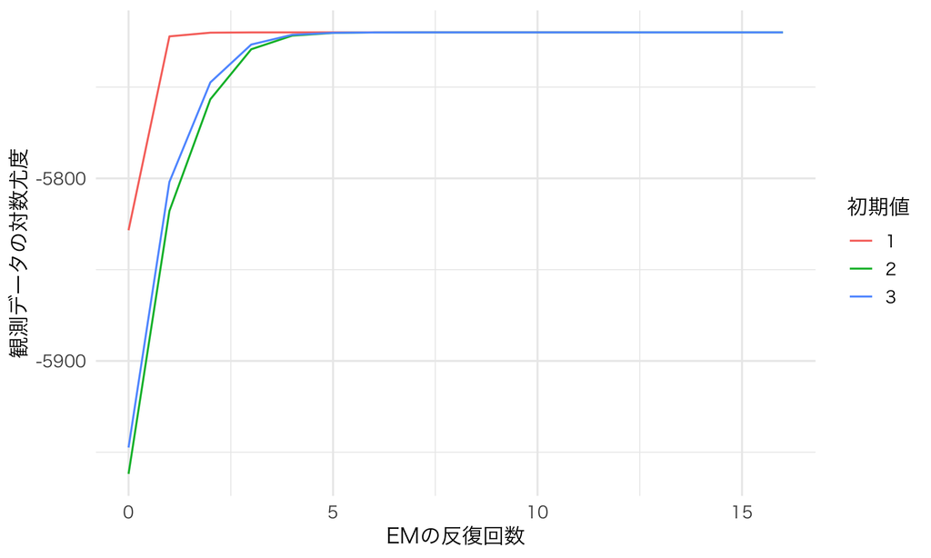

EMの3つの初期値からの対数尤度。単調に増えても、大域的な最大値とは限らない。

```r
em_trace <- do.call(rbind, lapply(seq_along(em_runs$fits), function(s) {
  f <- em_runs$fits[[s]]
  data.frame(iteration = seq_along(f$trace) - 1, loglik = f$trace, start = factor(s))
}))
ggplot(em_trace, aes(iteration, loglik, color = start)) + geom_line() +
  labs(x = "EMの反復回数", y = "観測データの対数尤度", color = "初期値")
```

候補値と割合を学んだ後、本人について得られるのは `em_fit$weights` の分布である。例えば顧客1の結果を、候補値を既知とした16機会の推定と比べる。

```r
ell16 <- panel_loglik(panel, theta_grid)
fit16 <- fit_known_pi(ell16)
knitr::kable(data.frame(type = 1:3, known_support = theta_grid,
                        known_weight = fit16$weights[1, ],
                        estimated_support = em_fit$theta,
                        estimated_weight = em_fit$weights[1, ]), digits = 3,
             col.names = c("タイプ", "既知の候補値", "既知の場合の重み",
                           "推定した候補値", "推定後の重み"))
```

| タイプ | 既知の候補値 | 既知の場合の重み | 推定した候補値 | 推定後の重み |
| --- | --- | --- | --- | --- |
| 1 | -1.5 | 0.000 | -1.504 | 0.000 |
| 2 | 0.0 | 0.003 | -0.014 | 0.002 |
| 3 | 1.5 | 0.997 | 1.458 | 0.998 |

### 4.9 識別とは、観測分布から一意に逆算できること

ここまでは最尤推定を計算してきた。しかし、計算が収束することと、データから母集団のタイプを区別できることは別の問題である。計量Iでいう**識別**に戻ろう。

価格列を所与として、母集団における履歴の確率を完全に知っていると考える。その確率から、タイプの候補値と割合 $\eta=(\pi,\vartheta)$ を一意に決められるだろうか。形式的には、同じ価格列のもとで次の含意が成り立つことをいう。確率の等式は、すべての選択列 $(a_1,\ldots,a_T)$ について要求する。

$$\begin{aligned}
&\Pr_\eta(y_{i1}=a_1,\ldots,y_{iT}=a_T)\\
&\qquad=\Pr_{\widetilde\eta}(y_{i1}=a_1,\ldots,y_{iT}=a_T)\\
&\qquad\Longrightarrow\quad \eta=\widetilde\eta.
\end{aligned}$$

ただし、タイプの番号だけを入れ替えても観測分布は変わらないので、$\vartheta_1<\vartheta_2<\vartheta_3$ と順序を決めておく。これはタイプの名前をそろえる約束である。

ここで知りたいのは、**母集団にどの好みが何割いるか**である。一人のタイプが3回の観測で確定するか、400人の標本で誤差なく推定できるか、という問いではない。人数を十分に増やして履歴の確率を正確に知れたとしても、異なる母集団が同じ観測分布を生むなら、データだけでは区別できない。

### 4.10 1回のシェアが同じでも、同じ人の履歴は違う

まず、1回の選択シェアだけでは足りない例を見よう。A・Bをともに150円に固定する。元の分布は候補値 $(-1.5,0,1.5)$、割合 $(0.25,0.50,0.25)$ だった。これとは別に、候補値 $(-2,0,2)$、割合を約 $(0.1829,0.6342,0.1829)$ とする分布を考える。後者は、より極端な好みの人を少なくし、中間の人を増やした分布である。

**1回のシェアは同じだが、履歴の確率は違う二つの母集団**

```r
ident_equal <- choice_prob(theta_grid, 1.5, 1.5)
ident_share <- drop(pi_true %*% ident_equal)
ident_alt_theta <- c(-2, 0, 2)
ident_alt_prob <- choice_prob(ident_alt_theta, 1.5, 1.5)
# 対称な分布なので、非購入のシェアを合わせればA・Bのシェアも合う。
ident_alt_w <- (1 / 3 - ident_share[1]) / (2 * (1 / 3 - ident_alt_prob[1, 1]))
ident_alt_pi <- c(ident_alt_w, 1 - 2 * ident_alt_w, ident_alt_w)
ident_alt_share <- drop(ident_alt_pi %*% ident_alt_prob)
knitr::kable(data.frame(
  quantity = c("1回で買わない確率", "1回でAを買う確率", "1回でBを買う確率", "同じ人が2回ともAを買う確率"),
  original = c(ident_share, sum(pi_true * ident_equal[, 2]^2)),
  alternative = c(ident_alt_share, sum(ident_alt_pi * ident_alt_prob[, 2]^2))),
  digits = 6, col.names = c("観測する量", "元の母集団", "別の母集団"))
```

| 観測する量 | 元の母集団 | 別の母集団 |
| --- | --- | --- |
| 1回で買わない確率 | 0.254312 | 0.254312 |
| 1回でAを買う確率 | 0.372844 | 0.372844 |
| 1回でBを買う確率 | 0.372844 | 0.372844 |
| 同じ人が2回ともAを買う確率 | 0.210229 | 0.207938 |

**1回のシェアは同じだが、履歴の確率は違う二つの母集団**

```r
stopifnot(max(abs(ident_share - ident_alt_share)) < 1e-12,
          all(ident_alt_pi > 0), abs(sum(ident_alt_pi) - 1) < 1e-12)
```

**1回ごとのシェアは同じだが、同じ人がAを買い続ける確率は違う。** 平均的な購入確率だけでは、好みの強さと、その好みを持つ人数の違いが隠れてしまう。同じ人の繰り返し選択には、その人の固定した好みが現れるため、追加の情報がある。

この点は、条件付き独立という仮定から分かる。タイプを固定すれば2回のショックは独立なので、価格を所与として

$$\Pr(y_{i1}=a,y_{i2}=b)
=\sum_{k=1}^3\pi_k
P_{a1}(\vartheta_k)P_{b2}(\vartheta_k),
\qquad a,b\in\{0,A,B\}.$$

**タイプを条件にすると独立だが、タイプを混ぜると、同じ人の選択どうしは一般に関連する。** 甘さ好きが1回目にも2回目にもBを買いやすいからである。別々の人の1回ずつの選択を並べても、この情報にはならない。

上の表は、2回の履歴を使えば、この二つの母集団を区別できることを示している。だが、これだけであらゆる3タイプの組を識別したわけではない。別の組合せなら、2回分の履歴まで同じにできるだろうか。

### 4.11 2回で残る曖昧さと、3回目が加える情報

この講義のように、全員が同じ価格列に直面し、3タイプの候補値も割合も未知の場合、**2回の選択だけでは、母集団のタイプ構成を一意に決められない。** 2回ともAを買った人の中には、苦味好き、中間タイプ、たまたまAを選んだ甘さ好きが混ざっている。「AAの人が何割いるか」が分かっても、その内訳には複数の説明が残る。

これを具体的に確かめるため、A・Bをともに150円に固定し、元の母集団と、次の別の母集団を比べる。この「別の母集団」は4.10のものとは異なり、**2回分の全9通りの履歴確率が一致するように構成した**ものである。

**同じ2回分の履歴確率を持つ別の母集団を構成する**

```r
# 構成の根拠は、この小節末尾の補足で説明する。
# z = exp(theta)、150円では d(z) = 1 + z + z^2。
ident_two_z <- exp(theta_grid)
ident_two_d <- 1 + ident_two_z + ident_two_z^2
ident_two_weight <- pi_true / ident_two_d^2
ident_two_m <- vapply(0:4, function(q) sum(ident_two_weight * ident_two_z^q), numeric(1))
# 3根を持つ多項式の2次の係数を変え、他の係数で同じモーメントを保つ。
ident_two_c2 <- -sum(ident_two_z) - .5
ident_two_hankel <- matrix(c(ident_two_m[1], ident_two_m[2],
                            ident_two_m[2], ident_two_m[3]), 2, 2)
ident_two_c01 <- solve(ident_two_hankel,
                       -ident_two_m[4:5] - ident_two_c2 * ident_two_m[3:4])
ident_two_roots <- polyroot(c(ident_two_c01, ident_two_c2, 1))
stopifnot(max(abs(Im(ident_two_roots))) < 1e-10)
ident_two_z_alt <- sort(Re(ident_two_roots))
ident_two_V <- rbind(1, ident_two_z_alt, ident_two_z_alt^2)
ident_two_weight_alt <- drop(solve(ident_two_V, ident_two_m[1:3]))
ident_two_theta_alt <- log(ident_two_z_alt)
ident_two_pi_alt <- ident_two_weight_alt * (1 + ident_two_z_alt + ident_two_z_alt^2)^2
ident_two_prob_alt <- choice_prob(ident_two_theta_alt, 1.5, 1.5)
ident_two_M <- t(ident_equal) %*% diag(pi_true) %*% ident_equal
ident_two_M_alt <- t(ident_two_prob_alt) %*% diag(ident_two_pi_alt) %*% ident_two_prob_alt
stopifnot(all(ident_two_z_alt > 0), all(ident_two_pi_alt > 0),
          abs(sum(ident_two_pi_alt) - 1) < 1e-10,
          max(abs(ident_two_M - ident_two_M_alt)) < 1e-10)
knitr::kable(data.frame(type = 1:3, theta = theta_grid, theta_alt = ident_two_theta_alt,
                        pi = pi_true, pi_alt = ident_two_pi_alt), digits = 6,
             col.names = c("タイプ", "元の候補値", "別の候補値", "元の割合", "別の割合"))
```

| タイプ | 元の候補値 | 別の候補値 | 元の割合 | 別の割合 |
| --- | --- | --- | --- | --- |
| 1 | -1.5 | -1.428742 | 0.25 | 0.272426 |
| 2 | 0.0 | 0.072567 | 0.50 | 0.501592 |
| 3 | 1.5 | 1.587181 | 0.25 | 0.225982 |

候補値も割合も違うが、観測できる2回分の履歴確率を計算すると、次のようになる。$0$ は「買わない」を表す。

```r
ident_two_histories <- expand.grid(first = c("0", "A", "B"), second = c("0", "A", "B"))
knitr::kable(data.frame(
  history = paste0(ident_two_histories$first, ident_two_histories$second),
  original = as.vector(ident_two_M), alternative = as.vector(ident_two_M_alt)),
  digits = 6, col.names = c("1・2回目の履歴", "元の母集団", "別の母集団"))
```

| 1・2回目の履歴 | 元の母集団 | 別の母集団 |
| --- | --- | --- |
| 00 | 0.070919 | 0.070919 |
| A0 | 0.091696 | 0.091696 |
| B0 | 0.091696 | 0.091696 |
| 0A | 0.091696 | 0.091696 |
| AA | 0.210229 | 0.210229 |
| BA | 0.070919 | 0.070919 |
| 0B | 0.091696 | 0.091696 |
| AB | 0.070919 | 0.070919 |
| BB | 0.210229 | 0.210229 |

**全9通りが同じなので、2回分だけを何人から集めても、この二つの母集団は区別できない。** 表の値は丸めているが、これは表示の丸めで同じに見えているだけではない。コードでも丸める前の9確率の一致を確認している。モデルの仮定のもとで、このような別の母集団を構成できることが非識別の理由である。

では、3回目を追加すると、どのような情報が増えるのだろうか。ここでも価格は同じで、各人の好みはそのまま固定している。**「全員をまとめて、3回目にBを買う割合を見ること」と、「最初の2回の履歴に紐づけて、3回目にBを買う割合を見ること」を比べよう。**

後者の例として、AAだった人に注目する。履歴ごとのタイプ構成を使うと、

$$\begin{aligned}
&\Pr(y_{i3}=B\mid y_{i1}=a,y_{i2}=b)\\
&\quad=\sum_{k=1}^3
\underbrace{\Pr(\theta_i=\vartheta_k\mid y_{i1}=a,y_{i2}=b)}_{\text{同じ履歴の人たちのタイプ構成}}
\underbrace{P_{B3}(\vartheta_k)}_{\text{タイプごとの次の選択確率}}.
\end{aligned}$$

となる。2回分の履歴確率が同じでも、その履歴の人たちのタイプ構成まで同じとは限らない。そこに、3回目で見分けられる違いが残っている。

```r
ident_two_B_given_AA <- sum(pi_true * ident_equal[, 2]^2 * ident_equal[, 3]) /
  ident_two_M[2, 2]
ident_two_B_given_AA_alt <- sum(ident_two_pi_alt * ident_two_prob_alt[, 2]^2 *
                                ident_two_prob_alt[, 3]) / ident_two_M_alt[2, 2]
knitr::kable(data.frame(
  quantity = c("3回目にBを買う確率：全員", "3回目にBを買う確率：AAだった人"),
  original = c(sum(pi_true * ident_equal[, 3]), ident_two_B_given_AA),
  alternative = c(sum(ident_two_pi_alt * ident_two_prob_alt[, 3]), ident_two_B_given_AA_alt)),
  digits = 6, col.names = c("観測する量", "元の母集団", "別の母集団"))
```

| 観測する量 | 元の母集団 | 別の母集団 |
| --- | --- | --- |
| 3回目にBを買う確率：全員 | 0.372844 | 0.372844 |
| 3回目にBを買う確率：AAだった人 | 0.118222 | 0.116820 |

```r
stopifnot(abs(ident_two_B_given_AA - ident_two_B_given_AA_alt) > 1e-4)
```

まず、表の**1行目が二つの母集団で同じ**であることが重要だ。全員をまとめた3回目のBの購入確率は、どちらも 0.372844、約 37.2844%である。2回分の全9通りの履歴確率が同じなら、それを集計して得られる1回分の全体シェアも同じになる。さらに、この例では価格とタイプ分布が毎回同じなので、3回目の全体シェアも一致する。Aや「買わない」の割合も同様である。したがって、**2回分の履歴に、3回目の全体シェアだけを追加しても、この二つの母集団は区別できない。**

次に、表の**2行目では違いが現れる**。AAだった人が次にBを買う確率は、元の母集団では約 11.822%、別の母集団では約 11.682%となる。AAという同じ履歴の人たちでも、その中に混ざっている好みの構成は異なる。その違いが、3回目の選択に現れるのである。

**この例で3回目が加える情報は、「最初の2回と3回目が、同じ人の中でどう結び付いているか」である。** 全員をプールして全体シェアだけを残すと、「Bを買ったのは、それまでにどんな履歴を持つ人だったか」という情報が失われる。同じ人の履歴に紐づけて集計すれば、AAだけでなくABやA0などについても、その後の選択との関係を使える。こうした履歴ごとの違いが、母集団のタイプ構成を絞る手がかりになる。

この例では二つの母集団を区別できた。モデルの仮定のもとで、3タイプの値と割合を一意に決められることは、4.12以降で示す。

**ノート補足：共通価格が2回の間で変わっても、なぜ2回では足りないのか**

以下も、タイプの値と割合がともに未知で、異なる有限の3タイプが正の割合を持つ場合を考える。価格列は全員に共通とし、その列に条件づける。人によって異なる価格列を与え、複数の価格条件の分布を組み合わせる設計は、ここでの議論の対象ではない。

$z_k=e^{\vartheta_k}$、$a_t=e^{1.5-p_{At}}$、$b_t=e^{1.5-p_{Bt}}$、$d_t(z)=a_t+z+b_tz^2$ と置くと、タイプ $k$ の選択確率は

$$P_{0t}(\vartheta_k)=\frac{z_k}{d_t(z_k)},\qquad
P_{At}(\vartheta_k)=\frac{a_t}{d_t(z_k)},\qquad
P_{Bt}(\vartheta_k)=\frac{b_tz_k^2}{d_t(z_k)}.$$

2回分の確率を掛けると、分子に現れる $z_k$ の次数は0から4までである。したがって、$\lambda_k=\pi_k/\{d_1(z_k)d_2(z_k)\}>0$ と置けば、9通りの履歴確率は、次の五つの量に既知の定数を掛けたものに尽きる。

$$m_q=\sum_{k=1}^3\lambda_k z_k^q,\qquad q=0,1,2,3,4.$$

ここで $\lambda_k$ は計算のために変換した正の重みで、合計が1とは限らない。例えば、AAの確率は $a_1a_2m_0$、00の確率は $m_2$、BBの確率は $b_1b_2m_4$ である。この五つを同じに保つ別の3点と正の重みが作れれば、全9通りを同じにできる。

そのため、3つの点 $z_1,z_2,z_3$ を根に持つ多項式

$$h(z)=z^3+c_2z^2+c_1z+c_0$$

を考える。各根で $h(z_k)=0$ なので、$\sum_k\lambda_k h(z_k)=0$ と $\sum_k\lambda_kz_kh(z_k)=0$ から、

$$\begin{aligned}
c_0m_0+c_1m_1+c_2m_2&=-m_3,\\
c_0m_1+c_1m_2+c_2m_3&=-m_4
\end{aligned}$$

を得る。係数は3個あるが、制約は2本である。$m_0m_2-m_1^2>0$ なので、$c_2$ を少し変え、そのたびに $c_0,c_1$ をこの2本から解くことができる。この不等式は、正の重みを持つ異なる点の分散が正であることに対応する。

十分小さな変化なら、多項式の3つの根は異なる正の値のままである。新しい根に対して $m_0,m_1,m_2$ が一致するように3つの重みを解くと、その重みも元の正の値の近くに保てる。上の2本の式により、$m_3,m_4$ も一致する。最後に $\pi_k=\lambda_kd_1(z_k)d_2(z_k)$ と戻すと、$d_1d_2$ は4次式なので、$m_0,\ldots,m_4$ が同じなら割合の合計も元と同じ1になる。

こうして、**異なる候補値と正の割合を持ちながら、2回分の観測分布がまったく同じ母集団を、元の分布の近くに作れる。** 上の数値例は、この構成を価格150円で実行したものである。

### 4.12 この3タイプモデルが識別できる条件

**重要命題：3回の選択の同時分布から、3タイプの値と割合を識別できる**

以下を仮定する。

1. タイプ数は $K=3$ と分かっており、候補値は有限で $\vartheta_1<\vartheta_2<\vartheta_3$、割合はすべて $\pi_k>0$ で合計1である。
2. 個人の $\theta_i$ は期間を通じて固定され、タイプと価格列を条件にすると、各機会の選択は独立である。
3. 「買わない・A・B」の3選択肢を観測する。選択確率は1.2のlogitで、$b_0=1.5$、$\alpha=1$、$x_A=-1$、$x_B=1$ は既知であり、ショックの尺度も固定されている。
4. 価格は各機会に全員に共通で、タイプや個人のショックと独立に設定される。以下では、その有限の価格列に条件づける。

このとき、同じ人の3回の選択の母集団同時分布から、$(\pi,\vartheta)$ は一意に決まる。タイプを順序づけなければ、番号の入れ替えを除いて一意である。

4.11では、全員に共通する一つの価格列のもとで、2回だけでは識別できないことを示した。したがって、**この講義の仮定のもとでは、3回が識別に必要かつ十分な観測回数となる。** 候補値を既知にする、人によって異なる価格条件を使うなど、設定を変えた場合の必要回数まで主張するものではない。また、タイプ数そのものをデータから決める定理でもない。

価格は3回とも同じでも、機会ごとに異なっていてもよい。この命題では、価格の変動ではなく、同じ人の繰り返し選択と、指定したlogitの形を使う。3.1のシミュレーションはこの条件を満たし、16機会のうち最初の3機会だけでも、以下の識別の議論を適用できる。

### 4.13 観測される二つの表から、タイプを取り出す

行列は、選択確率を表としてまとめるために使う。機会 $t$ のタイプ別選択確率を

$$R_t=
\begin{pmatrix}
P_{0t}(\vartheta_1)&P_{0t}(\vartheta_2)&P_{0t}(\vartheta_3)\\
P_{At}(\vartheta_1)&P_{At}(\vartheta_2)&P_{At}(\vartheta_3)\\
P_{Bt}(\vartheta_1)&P_{Bt}(\vartheta_2)&P_{Bt}(\vartheta_3)
\end{pmatrix}$$

と書く。**行は選択肢、列はタイプ**であり、各列の合計は1である。この $R_t$ 自体は、タイプが見えないため直接は観測できない。

まず必要なのは、$R_1,R_2$ の列が線形独立であることだ。これは、3タイプの確率の列が、二つ以下の列の組合せに潰れていないという条件である。正方行列の場合、この条件が満たされると逆行列が存在し、行列を掛ける操作を元に戻せる。

このlogitでは、候補値が異なるだけで、この条件が満たされる。さらに、$\vartheta$ が大きいほどBの購入確率は厳密に高くなる。この二点を確認してから、観測分布からの逆算に進もう。

**ノートなぜこのlogitでは、列が線形独立で、Bの確率も異なるのか**

$z_k=e^{\vartheta_k}>0$、$a_t=e^{1.5-p_{At}}>0$、$b_t=e^{1.5-p_{Bt}}>0$ と置くと、$R_t$ の第 $k$ 列は

$$\frac{1}{1+a_t/z_k+b_tz_k}
\begin{pmatrix}1\\a_t/z_k\\b_tz_k\end{pmatrix}$$

である。各列を正の数 $z_k(1+a_t/z_k+b_tz_k)$ 倍すると、列は $(z_k,a_t,b_tz_k^2)'$ になる。行の順番を入れ替え、正の定数で割れば、次の行列になる。

$$V=\begin{pmatrix}
1&1&1\\ z_1&z_2&z_3\\ z_1^2&z_2^2&z_3^2
\end{pmatrix},\qquad
\det V=(z_2-z_1)(z_3-z_1)(z_3-z_2)\ne0.$$

$\det$ は行列式で、0でなければ逆行列が存在する。ここでは $z_k$ がすべて異なるので0にならない。直感的には、放物線上の異なる3点 $(z_k,z_k^2)$ は一本の直線上に並ばない。この独立な違いが、3タイプの選択確率にも残る。列や行を正の数で伸縮しても、線形独立かどうかは変わらないので、元の $R_t$ も可逆である。

また、logit公式を微分すると、

$$\frac{\partial P_{Bt}(\theta)}{\partial\theta}
=P_{Bt}(\theta)\{P_{0t}(\theta)+2P_{At}(\theta)\}>0.$$

したがって、$\vartheta_1<\vartheta_2<\vartheta_3$ なら、$P_{B3}(\vartheta_1)<P_{B3}(\vartheta_2)<P_{B3}(\vartheta_3)$ である。

**ステップ1：観測される二つの表を書く。**

1・2回目の選択の同時確率を並べた $3\times3$ の表を $M$ とし、そこに「3回目はB」という条件も加えた同時確率の表を $M_B$ とする。

$$M_{ab}=\Pr(y_{i1}=a,y_{i2}=b),\qquad
(M_B)_{ab}=\Pr(y_{i1}=a,y_{i2}=b,y_{i3}=B).$$

行と列はともに $0,A,B$ の順である。$M_B$ は、Bを買った人の中だけで正規化した条件付き確率ではない。全セルの合計は $\Pr(y_{i3}=B)$ となる。

$D_\pi=\operatorname{diag}(\pi_1,\pi_2,\pi_3)$、$D_B=\operatorname{diag}(P_{B3}(\vartheta_1),P_{B3}(\vartheta_2),P_{B3}(\vartheta_3))$ とする。$\operatorname{diag}$ は、指定した数を対角線上に置き、他の成分を0にした行列である。条件付き独立から、

$$M=R_1D_\pi R_2',\qquad
M_B=R_1D_\pi D_B R_2'$$

と書ける。$'$ は行と列を入れ替える転置を表す。例えば、右辺の $(a,b)$ 成分は、それぞれ $\sum_k\pi_kP_{a1}(\vartheta_k)P_{b2}(\vartheta_k)$ と、それにタイプごとの $P_{B3}(\vartheta_k)$ を掛けた和である。二つの表の違いは、3回目にBを買いやすいタイプがどれだけ重く入るかだ。

**ステップ2：共通の混ざり方を消し、タイプごとの違いを残す。**

$R_1,R_2$ は可逆で、$\pi_k>0$ なので $D_\pi$ も可逆である。したがって $M$ も可逆となり、観測される表だけから

$$\begin{aligned}
C&=M_BM^{-1}\\
&=R_1D_\pi D_B R_2'(R_2')^{-1}D_\pi^{-1}R_1^{-1}\\
&=R_1D_B R_1^{-1}.
\end{aligned}$$

を計算できる。ここで $M^{-1}$ は行列としての逆であり、各セルを逆数にする操作ではない。二つの表を組み合わせると、タイプ割合と2回目の選択確率が消え、1回目のタイプ別確率と、3回目にBを買うタイプ別確率が残った。

**ステップ3：タイプ別の選択確率を復元する。**

$R_1$ の第 $k$ 列を $r_{1k}$ とすると、上の式は

$$C r_{1k}=P_{B3}(\vartheta_k)\,r_{1k}$$

を意味する。つまり、$C$ を掛けても向きが変わらず、倍率だけが変わる列が、タイプ別の選択確率である。このような列を**固有ベクトル**、その倍率を**固有値**と呼ぶ。

3つの倍率 $P_{B3}(\vartheta_k)$ は異なるので、$C$ の3つの固有ベクトルの方向がそれぞれ一意に決まる。固有ベクトルは何倍してもよいが、ここでは確率の列だから合計が1になるように正規化する。これで $R_1$ を復元できる。固有値の小さい順に並べれば、好みの小さい順にタイプの番号もそろう。

**ステップ4：選択確率から好みと割合を戻す。**

1回目の選択確率の比を取ると、logitの共通の分母が消える。

$$\frac{P_{B1}(\vartheta_k)}{P_{01}(\vartheta_k)}
=e^{1.5+\vartheta_k-p_{B1}}
\quad\Longrightarrow\quad
\vartheta_k=\log\frac{(R_1)_{B,k}}{(R_1)_{0,k}}-1.5+p_{B1}.$$

価格と定数は既知なので、候補値を一意に戻せる。最後に、観測される1回目のシェアを $s_1=(\Pr(y_{i1}=0),\Pr(y_{i1}=A),\Pr(y_{i1}=B))'$ とすると、

$$s_1=R_1\pi
\quad\Longrightarrow\quad
\pi=R_1^{-1}s_1.$$

したがって、**観測される3回の同時分布 → タイプ別の選択確率 → タイプの値と割合**という逆算ができる。同じ観測分布を生む別のパラメータも、この同じ逆算結果に一致しなければならない。これで命題が示された。

### 4.14 母集団の確率を使い、逆算を数値で確かめる

今の証明を、3.1と同じ価格列の最初の3機会で確認する。ここでは識別の計算を確かめるため、既知の生成値から27通りの履歴の**母集団確率**を作る。その後の逆算関数には、この27個の確率と既知の価格だけを渡す。候補値と割合は渡さない。

**3回の同時分布を作り、タイプの値と割合を逆算する**

```r
# ここだけは識別の検算用。標本頻度ではなく、生成モデルの母集団確率を作る。
ident_R <- lapply(1:3, function(tt) {
  t(choice_prob(theta_grid, prices$pA[tt], prices$pB[tt]))
})
ident_joint <- array(0, dim = c(3, 3, 3))
for (k in 1:3) {
  for (j in 1:3) {
    ident_joint[, , j] <- ident_joint[, , j] +
      pi_true[k] * ident_R[[3]][j, k] * outer(ident_R[[1]][, k], ident_R[[2]][, k])
  }
}
# 入力は母集団の27セルと、1回目のB価格。真の候補値・割合は引数にしない。
recover_three_types <- function(joint, pB1) {
  M <- apply(joint, c(1, 2), sum)
  MB <- joint[, , 3]
  C <- MB %*% solve(M)
  eig <- eigen(C)
  stopifnot(max(abs(Im(eig$values))) < 1e-10,
            max(abs(Im(eig$vectors))) < 1e-10)
  order_type <- order(Re(eig$values))
  R1 <- Re(eig$vectors[, order_type])
  R1 <- sweep(R1, 2, colSums(R1), "/")
  theta <- log(R1[3, ] / R1[1, ]) - 1.5 + pB1
  pi <- drop(solve(R1, rowSums(M)))
  list(theta = theta, pi = pi, R1 = R1)
}
ident_recovered <- recover_three_types(ident_joint, prices$pB[1])
knitr::kable(data.frame(type = 1:3, theta = theta_grid,
                        recovered_theta = ident_recovered$theta,
                        pi = pi_true, recovered_pi = ident_recovered$pi), digits = 6,
             col.names = c("タイプ", "生成時の候補値", "逆算した候補値", "生成時の割合", "逆算した割合"))
```

| タイプ | 生成時の候補値 | 逆算した候補値 | 生成時の割合 | 逆算した割合 |
| --- | --- | --- | --- | --- |
| 1 | -1.5 | -1.5 | 0.25 | 0.25 |
| 2 | 0.0 | 0.0 | 0.50 | 0.50 |
| 3 | 1.5 | 1.5 | 0.25 | 0.25 |

**3回の同時分布を作り、タイプの値と割合を逆算する**

```r
stopifnot(abs(sum(ident_joint) - 1) < 1e-12,
          max(abs(ident_recovered$theta - theta_grid)) < 1e-10,
          max(abs(ident_recovered$pi - pi_true)) < 1e-10)
```

元の候補値と割合を回収できた。これは、**母集団確率からの逆算を確認した結果**であり、400人のデータから誤差なく推定できたという結果ではない。実際の有限標本では27セルの頻度に誤差があり、この逆算をそのまま当てはめると、負の確率や複素数の固有値が出ることもある。識別を示す計算と、安定した推定方法は区別する。前に行ったEMは、logitと確率の制約を保って標本の尤度を最大化するための計算法である。

### 4.15 識別できる範囲と、データが少ないときの難しさ

証明のどこで各仮定が必要だったかを振り返ろう。

- **候補値が二つ一致する場合**：タイプ別確率の列も一致して $R_t$ が可逆でなくなり、区別できるのはその二つの割合の合計になる。
- **あるタイプの割合が0の場合**：そのタイプは観測分布に現れず、その候補値を決められない。$D_\pi$ も可逆ではなくなる。
- **タイプを条件にしても選択が依存する場合**：例えば前回の購入が今回の効用を変える状態依存があると、今使った3つの確率の積では同時分布を表せない。そのモデルについて別の識別の議論が必要になる。
- **選択肢や未知パラメータを変える場合**：非購入を記録しない、価格係数も未知にする、タイプ数も選ぶ、といった変更には、この命題をそのまま使えない。

候補値が一致していなくても非常に近いときや、割合が正でも非常に小さいときは、母集団では識別できても、有限標本では区別が難しくなる。行列が可逆でも、観測確率の小さな誤差が逆算で大きくなるからだ。したがって、3回で識別できることは、3回で精度も十分だという意味ではない。16機会を使うことや、人数を増やすことには、推定を安定させる役割がある。

最後に、**母集団の候補値と割合が分かっても、一人のタイプは確定しない。** このlogitでは有限の候補値でどの選択も正の確率を持つ。有限回の履歴と正のタイプ割合のもとでは、各タイプの事後確率も正のままである。識別できた母集団分布を使って、その人がどのタイプらしいかを確率として更新する、という講義の問いは残る。

**ヒント研究コラム：条件付き独立な繰り返し観測を識別に使う**

Allman, Matias and Rhodes (2009) は、潜在クラスを条件に独立となる複数の観測から、混合割合とクラス別分布を識別する条件を整理している。本節ではその一般定理をそのまま仮定する代わりに、今回の3タイプ・3選択肢のlogitについて、必要な行列の独立性を確かめ、観測分布からの逆算を示した。より一般的な有限混合モデルでは、タイプの数と観測の種類に応じて条件を検討する必要がある。[Allman, Matias and Rhodes (2009), §4, Corollary 2](https://www.cs.uaf.edu/~jrhodes/papers/Latent.pdf)

Kasahara and Shimotsuの研究は、有限混合の離散選択モデルで、パネルの長さ、説明変数の変動、状態依存などが識別にどう関わるかを扱う。今回の「固定した好みを条件に選択が独立」という仮定を緩めるときのつながりになる。[笠原・下津による日本語解説（2015）、§2・3](https://www.jstage.jst.go.jp/article/jjssj/44/2/44_451/_pdf/-char/en)

## 5. 正規分布のrandom coefficient logitをEMで推定する

これまでは甘さの好みが3つの値のどれかだと仮定した。実際には、好みはその間の値も取り得る。そこで今度は

$$\theta_i\sim N(\mu,\tau^2),\qquad
u_{ijt}=1.5+\theta_i x_j-p_{jt}+\varepsilon_{ijt}$$

とする。$x_A=-1$、$x_B=1$、「買わない」の効用は $\varepsilon_{i0t}$ で、前と同じ標準Gumbelショックを使う。$\mu$ は好みの母集団平均、$\tau$ は個人差の標準偏差だ。連続分布にしたのは**甘さへの好み**であり、価格係数ではない。価格は引き続き、同じ機会には全員に共通とする。

第4節では、割合の更新は簡単な式になったが、タイプの候補値の更新には数値的な最適化が残った。この正規分布モデルでは、**各人の事後分布が求まれば、推定したい母集団の平均と分散を、どちらも集計式で更新できる。** ここでは、その利点を生かしてEMで推定する。

### 5.1 別のデータで連続分布を試す

以下では、有限3タイプの例とは別に、200人を各8機会観測するデータを作る。生成する側の真値は $(\mu,\tau)=(0.2,1)$ とし、各人の $\theta_i$ を一度だけ引き、全8機会で固定する。機会ごとの価格をそれぞれ一度引いて全員に共通に提示する。`theta_true_c` は結果を確認するために保存するが、推定には渡さない。

```r
# 連続的な好み：同じ選択モデルで独立のデータを生成する
set.seed(202607)
N_c <- 200; T_c <- 8
mu_true_c <- 0.2; tau_true_c <- 1
id_c <- rep(seq_len(N_c), each = T_c)
time_c <- rep(seq_len(T_c), times = N_c)
price_c <- data.frame(pA = runif(T_c, 1, 2.5), pB = runif(T_c, 1, 2.5))
theta_true_c <- rnorm(N_c, mu_true_c, tau_true_c)
pA_c <- price_c$pA[time_c]; pB_c <- price_c$pB[time_c]
prob_c <- function(theta, pA, pB) {
  va <- 1.5 - theta - pA; vb <- 1.5 + theta - pB
  m <- pmax(0, va, vb)
  e <- cbind(exp(-m), exp(va - m), exp(vb - m))
  e / rowSums(e)
}
probs_c <- prob_c(theta_true_c[id_c], pA_c, pB_c)
u_c <- runif(N_c * T_c)
y_c <- as.integer(u_c > probs_c[,1]) + as.integer(u_c > probs_c[,1] + probs_c[,2])
dat_c <- data.frame(id = id_c, time = time_c, pA = pA_c, pB = pB_c, y = y_c)
```

### 5.2 推定するのは母集団の平均と分散

$H_i$ は本人の選択列と、各機会に提示された価格を含む履歴で、$L(\theta;H_i)$ は、好みが $\theta$ なら本人の選択列が観測される確率だった。有限タイプの和を積分に置き換えると、母集団の周辺対数尤度は

$$\ell(\mu,\tau;\mathcal H)=
\sum_{i=1}^N\log\left\{\int L(\theta;H_i)
\frac{1}{\tau}\phi\!\left(\frac{\theta-\mu}{\tau}\right)d\theta\right\}$$

である。$\phi$ は標準正規密度、$\tau>0$ とする。**一人の履歴の確率を先に掛けてから、全機会に共通する $\theta$ について積分する。** 目的は、この対数尤度を大きくする $\mu,\tau$ を求めることだ。以下では更新式を分かりやすくするため、標準偏差 $\tau$ の代わりに分散 $\tau^2$ を更新する。

もし各人の $\theta_i$ まで観測できたら、話は簡単である。$\theta_i$ を固定すると、logitの尤度 $L(\theta_i;H_i)$ に $\mu,\tau^2$ は入らない。この二つが入るのは、母集団の正規密度だけだ。したがって、完全データでの最尤推定は、$\theta_i$ の標本平均と、そこからの二乗偏差を $N$ で割った分散を求めればよい。

実際には $\theta_i$ が見えない。そこで、第4節と同じく、現在のパラメータで各人の事後分布を求め、その分布について完全データ対数尤度の期待値を取る。**有限タイプでは所属の確率を使ったが、ここでは連続的な好みについての平均と分散を使う。** その計算をE・Mステップに分けて進めよう。

### 5.3 Eステップ：各人の事後平均と事後分散を求める

反復 $r$ の母集団パラメータを $\mu^{(r)},(\tau^2)^{(r)}$ とする。Eステップでは、その現在値を事前分布に使って、各人の履歴でベイズ更新する。

$$f_i^{(r)}(\theta)
=\frac{L(\theta;H_i)f_N(\theta;\mu^{(r)},(\tau^2)^{(r)})}
{\int L(s;H_i)f_N(s;\mu^{(r)},(\tau^2)^{(r)})\,ds}.$$

ここで $f_N(\theta;\mu,\tau^2)=\phi((\theta-\mu)/\tau)/\tau$ は平均 $\mu$、分散 $\tau^2$ の正規密度である。第4節の「割合×尤度を正規化する」計算が、「密度×尤度を積分で正規化する」計算になった。

この事後分布のもとでの平均と分散を

$$\begin{aligned}
m_i^{(r)}&=E_r[\theta_i\mid H_i]
=\int\theta f_i^{(r)}(\theta)\,d\theta,\\
v_i^{(r)}&=\operatorname{Var}_r(\theta_i\mid H_i)
=\int(\theta-m_i^{(r)})^2f_i^{(r)}(\theta)\,d\theta
\end{aligned}$$

と書く。添字 $r$ は、期待値や分散を計算する際に使うパラメータを現在値に固定することを表す。$m_i^{(r)}$ はその人の好みの中心、$v_i^{(r)}$ はその人についてまだ残る不確かさである。

母集団が正規分布でも、logitの履歴を取り込んだ事後分布は一般に正規分布ではない。そのため、これらの積分は数値的に計算する。以下では $[-6,6]$ を241点に分け、台形則で近似する。正規分布のsupportは実数全体であり、この有限範囲は計算上の近似である。また、連続分布の特定の一点の確率は0で、更新するのは点の確率ではなく密度だ。端の外側の寄与と格子の細かさは5.7で確認する。

**数値積分の準備：周辺対数尤度と事後分布の重み**

```r
# 台形則で係数空間を積分する。両端に半分の重みを付ける。
theta_nodes_c <- seq(-6, 6, length.out = 241)
trap_weights_c <- function(x) {
  dx <- diff(x)
  stopifnot(max(abs(dx - dx[1])) < 1e-10)
  c(dx[1] / 2, rep(dx[1], length(x) - 2), dx[1] / 2)
}
theta_w_c <- trap_weights_c(theta_nodes_c)
log_lik_c <- function(dat, nodes = theta_nodes_c) {
  sapply(nodes, function(th) {
    pr <- prob_c(th, dat$pA, dat$pB)
    drop(rowsum(log(pr[cbind(seq_len(nrow(dat)), dat$y + 1)]), dat$id))
  })
}
ell_c <- log_lik_c(dat_c)
rowmax_c <- apply(ell_c, 1, max)
lik_c <- exp(ell_c - rowmax_c)
# 全員の周辺対数尤度。各人について引いた標準化分を足し戻す。
marginal_loglik_c <- function(mu, log_tau, nodes = theta_nodes_c,
                              node_w = theta_w_c, lik = lik_c, rowmax = rowmax_c) {
  weights <- dnorm(nodes, mu, exp(log_tau)) * node_w
  values <- drop(lik %*% weights)
  if (any(values <= 0) || any(!is.finite(values))) return(-Inf)
  sum(rowmax + log(values))
}
post_weights_c <- function(mu, tau, lik = lik_c, nodes = theta_nodes_c, node_w = theta_w_c) {
  weights <- dnorm(nodes, mu, tau) * node_w
  z <- sweep(lik, 2, weights, "*")
  z / rowSums(z)
}
```

`post_weights_c()` の各行は、一人の事後分布を格子上で近似した重みで、合計は1になる。尤度の対数から各人の最大値を引いているのは、小さすぎる数を直接扱わないための工夫である。この重みから、平均と分散を計算する。

```r
posterior_moments_c <- function(mu, tau, lik = lik_c,
                                nodes = theta_nodes_c, node_w = theta_w_c) {
  w <- post_weights_c(mu, tau, lik, nodes, node_w)
  m <- drop(w %*% nodes)
  centered <- sweep(matrix(nodes, nrow(w), length(nodes), byrow = TRUE), 1, m, "-")
  v <- rowSums(w * centered^2)
  list(mean = m, variance = v)
}
mu0_c <- 0; tau0_c <- 1
e0_c <- posterior_moments_c(mu0_c, tau0_c)
knitr::kable(data.frame(customer = 1:3, mean = e0_c$mean[1:3],
                        variance = e0_c$variance[1:3]), digits = 4,
             col.names = c("顧客", "初期値での事後平均", "初期値での事後分散"))
```

| 顧客 | 初期値での事後平均 | 初期値での事後分散 |
| --- | --- | --- |
| 1 | -0.1359 | 0.1844 |
| 2 | 0.6477 | 0.2198 |
| 3 | 1.1377 | 0.2768 |

初期値は $(\mu^{(0)},\tau^{(0)})=(0,1)$ とした。真値を渡したわけではない。表は最初の3人だけを示しているが、`e0_c` には200人全員の結果が入っている。同じ仮の母集団分布から始めても、履歴が違うので、事後平均と事後分散は人によって異なる。

### 5.4 Mステップ：母集団の平均と分散を集計式で更新する

次に、Eステップで得た各人の事後分布 $f_i^{(r)}$ を固定し、母集団パラメータ $\mu,\tau^2$ を動かす。最大化する関数 $Q$ は、第4節と同じく、**完全データ対数尤度を、見えていない好みについて事後分布で平均したもの**である。その式を順に作ろう。

**まず、好み $\theta_i$ まで観測できた場合を考える。** 一人分の完全データは、履歴 $H_i$ と好み $\theta_i$ の組である。その尤度への寄与は、好みの母集団密度 $f_N(\theta_i;\mu,\tau^2)$ と、その好みのもとで履歴が起こる確率 $L(\theta_i;H_i)$ の積になる。対数を取り、正規密度の式を代入すると、

$$\begin{aligned}
\log\{L(\theta_i;H_i)f_N(\theta_i;\mu,\tau^2)\}
&=\log L(\theta_i;H_i)+\log f_N(\theta_i;\mu,\tau^2)\\
&=\log L(\theta_i;H_i)-\frac12\log(2\pi)
-\frac12\log\tau^2-\frac{(\theta_i-\mu)^2}{2\tau^2}.
\end{aligned}$$

これを全員分足すと、完全データ対数尤度になる。$\theta_i$ を固定すれば、最初の $\log L(\theta_i;H_i)$ に $\mu,\tau^2$ は入らない。この二つが入るのは、正規密度から出てきた最後の二項である。

**次に、観測できない $\theta_i$ について平均する。** 一つの好みの値で埋めるのではなく、5.3で求めた $f_i^{(r)}$ を使って、上の対数を平均する。これが $Q$ の定義である。

$$\begin{aligned}
Q(\mu,\tau^2\mid\mu^{(r)},(\tau^2)^{(r)})
&=\sum_i E_r[\log L(\theta_i;H_i)+\log f_N(\theta_i;\mu,\tau^2)\mid H_i]\\
&=\sum_i\int\{\log L(\theta;H_i)+\log f_N(\theta;\mu,\tau^2)\}
f_i^{(r)}(\theta)\,d\theta.
\end{aligned}$$

ここで、平均するための分布 $f_i^{(r)}$ は更新前のパラメータで作ったまま固定する。一方、対数の中の正規密度には、これから比較する候補 $\mu,\tau^2$ を入れる。$Q$ の縦棒の右側は分布を固定するための現在値、左側はMステップで動かす候補値である。

先ほど展開した式の各項を平均しよう。$\log\tau^2$ は $\theta_i$ によらないので平均しても変わらず、全員分足すと $-\frac N2\log\tau^2$ になる。二乗偏差 $(\theta_i-\mu)^2$ は好みによって変わるので、その期待値を取る。残りをまとめると、

$$Q(\mu,\tau^2\mid\mu^{(r)},(\tau^2)^{(r)})
=-\frac{N}{2}\log\tau^2
-\frac{1}{2\tau^2}\sum_i E_r[(\theta_i-\mu)^2\mid H_i]+C_r$$

となる。ここで $C_r=\sum_i E_r[\log L(\theta_i;H_i)\mid H_i]-\frac N2\log(2\pi)$ は、候補の $\mu,\tau^2$ に依存しない項である。履歴の尤度がこの定数に入るのは、平均する事後分布を固定しているためだ。履歴の情報はその事後分布にすでに反映されており、Mステップでも二乗偏差の期待値を通じて更新に使われる。

あとは、Eステップで計算した平均と分散を使えばよい。二乗偏差の期待値を

$$E_r[(\theta_i-\mu)^2\mid H_i]
=v_i^{(r)}+(m_i^{(r)}-\mu)^2$$

と分解し、$\mu\in\mathbb R$ と $\tau^2>0$ について最大化すると、次の更新式が得られる。

$$\begin{aligned}
\mu^{(r+1)}&=\frac1N\sum_i m_i^{(r)},\\
(\tau^2)^{(r+1)}
&=\frac1N\sum_i\{v_i^{(r)}+(m_i^{(r)}-\mu^{(r+1)})^2\}.
\end{aligned}$$

**母集団平均は、本人ごとの事後平均を平均する。母集団分散は、「本人について残る不確かさ」と「本人ごとの平均の違い」を合わせる。** $m_i^{(r)}$ を観測された好みのように扱い、そのばらつきだけで分散を更新すると、$v_i^{(r)}$ の分を落としてしまう。見えていない $\theta_i$ を一つの推定値で置き換えるだけでは足りない。

最初のEステップの結果を、この式に入れてみよう。

```r
mu1_c <- mean(e0_c$mean)
tau1_c <- sqrt(mean(e0_c$variance + (e0_c$mean - mu1_c)^2))
ll0_c <- marginal_loglik_c(mu0_c, log(tau0_c))
ll1_c <- marginal_loglik_c(mu1_c, log(tau1_c))
knitr::kable(data.frame(stage = c("初期値", "1回目の更新後"),
                        mu = c(mu0_c, mu1_c), tau = c(tau0_c, tau1_c),
                        loglik = c(ll0_c, ll1_c)), digits = 4,
             col.names = c("計算の段階", "母集団平均 μ", "個人差の標準偏差 τ", "周辺対数尤度"))
```

| 計算の段階 | 母集団平均 μ | 個人差の標準偏差 τ | 周辺対数尤度 |
| --- | --- | --- | --- |
| 初期値 | 0.0000 | 1.0000 | -1566.210 |
| 1回目の更新後 | 0.1736 | 0.9323 | -1561.236 |

```r
stopifnot(ll1_c >= ll0_c - 1e-7)
```

**このMステップには `optim()` も `optimize()` も出てこない。** 200人分の事後平均・事後分散を集計するだけで、母集団パラメータを更新できる。第4節の候補値の更新との違いは、ここにある。なお、コードでは分散の更新式の平方根を取り、標準偏差 $\tau$ を保存している。

### 5.5 更新を繰り返して母集団の分布を推定する

新しい $\mu,\tau$ で各人の事後分布を求め直し、その平均と分散で母集団パラメータを更新する。本人の履歴は同じまま、このE・Mの組を繰り返す。第4節と同様に、止めるかどうかは観測データの周辺対数尤度で判断する。

**EMの反復：事後平均・事後分散から母集団パラメータを更新する**

```r
fit_em_normal_c <- function(mu_init = 0, tau_init = 1, tol = 1e-8, maxit = 500,
                            nodes = theta_nodes_c, node_w = theta_w_c,
                            lik = lik_c, rowmax = rowmax_c) {
  mu <- mu_init; tau <- tau_init
  ll <- marginal_loglik_c(mu, log(tau), nodes, node_w, lik, rowmax)
  trace <- data.frame(iteration = 0, mu = mu, tau = tau, loglik = ll)
  for (r in seq_len(maxit)) {
    # Eステップ：今の母集団パラメータで、各人の平均と分散を求める。
    moments <- posterior_moments_c(mu, tau, lik, nodes, node_w)
    # Mステップ：Eステップの結果を固定したまま、集計式で更新する。
    mu_new <- mean(moments$mean)
    tau_new <- sqrt(mean(moments$variance + (moments$mean - mu_new)^2))
    ll_new <- marginal_loglik_c(mu_new, log(tau_new), nodes, node_w, lik, rowmax)
    stopifnot(is.finite(ll_new), tau_new > 0, ll_new >= ll - 1e-7)
    gain <- ll_new - ll
    trace <- rbind(trace, data.frame(iteration = r, mu = mu_new,
                                    tau = tau_new, loglik = ll_new))
    mu <- mu_new; tau <- tau_new; ll <- ll_new
    if (abs(gain) < tol) return(list(mu = mu, tau = tau, trace = trace))
  }
  stop("Normal random coefficient EM did not converge")
}
fit_c <- fit_em_normal_c(mu0_c, tau0_c)
mu_hat_c <- fit_c$mu; tau_hat_c <- fit_c$tau
stopifnot(max(abs(unlist(fit_c$trace[2, c("mu", "tau")]) - c(mu1_c, tau1_c))) < 1e-12)
```

```r
knitr::kable(data.frame(parameter = c("母集団平均 μ", "個人差の標準偏差 τ"),
                        truth = c(mu_true_c, tau_true_c),
                        estimate = c(mu_hat_c, tau_hat_c)), digits = 4,
             col.names = c("パラメータ", "真値", "EMによる推定値"))
```

| パラメータ | 真値 | EMによる推定値 |
| --- | --- | --- |
| 母集団平均 μ | 0.2 | 0.2136 |
| 個人差の標準偏差 τ | 1.0 | 0.8666 |

この計算は 19 回の更新で、周辺対数尤度の変化が $10^{-8}$ 未満になった。推定値は真値そのものではない。有限の人数と履歴から得た一回の推定結果である。

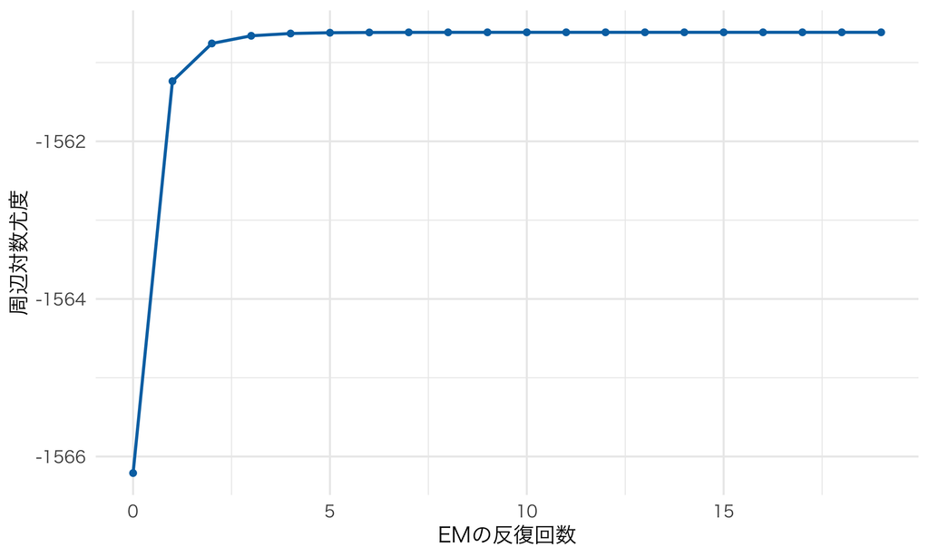

図 1: 正規分布モデルのEMによる周辺対数尤度の推移。Eステップの積分には241点の台形則を使っている。

```r
ggplot(fit_c$trace, aes(iteration, loglik)) +
  geom_line(linewidth = .9, color = "#0072B2") + geom_point(size = 1.5, color = "#0072B2") +
  labs(x = "EMの反復回数", y = "周辺対数尤度")
```

**簡単になったのはMステップであり、積分が不要になったわけではない。** Eステップでは、正規分布とは限らない各人の事後分布について積分する必要がある。上の式は正確な期待値を用いる理論上の更新式で、ここではそれを数値積分で実装した。積分の精度と、反復が収束したかどうかは別に確認する。

この例の母集団パラメータは2個なので、直接最適化も十分扱える。一方、複数の商品属性について個人ごとの係数を持たせ、正規分布の平均ベクトルや共分散まで推定する場合にも、必要な事後平均・共分散が得られれば、Mステップは同様の集計式になる。これがこの構造を使う利点である。ただし、係数が多くなるとEステップの積分も難しくなる。直接最適化でも周辺尤度を評価するために積分が必要であり、どちらが速いかは問題による。

**ノート補足：直接最適化でも同じ推定問題を解ける**

EMは最尤推定の計算法の一つである。同じ数値積分で求めた周辺対数尤度を、`optim()` で直接最大化することもできる。$\tau>0$ を満たすため、動かす変数を $\mu$ と $\log\tau$ にする。

```r
fit_direct_c <- optim(c(0, 0), function(a) -marginal_loglik_c(a[1], a[2]),
                       method = "BFGS", control = list(reltol = 1e-12, maxit = 1000))
stopifnot(fit_direct_c$convergence == 0)
direct_values_c <- c(fit_direct_c$par[1], exp(fit_direct_c$par[2]))
knitr::kable(data.frame(method = c("EM", "直接最適化"),
                        mu = c(mu_hat_c, direct_values_c[1]),
                        tau = c(tau_hat_c, direct_values_c[2]),
                        loglik = c(tail(fit_c$trace$loglik, 1), -fit_direct_c$value)),
             digits = 6, col.names = c("計算法", "母集団平均 μ", "標準偏差 τ", "周辺対数尤度"))
```

| 計算法 | 母集団平均 μ | 標準偏差 τ | 周辺対数尤度 |
| --- | --- | --- | --- |
| EM | 0.213620 | 0.866561 | -1560.616 |
| 直接最適化 | 0.213619 | 0.866557 | -1560.616 |

```r
stopifnot(max(abs(c(mu_hat_c, tau_hat_c) - direct_values_c)) < 1e-4,
          abs(tail(fit_c$trace$loglik, 1) + fit_direct_c$value) < 1e-6)
```

このデータでは二つの計算法がほぼ同じ結果に到達した。これは今回の計算での確認であり、一般に同じ解への収束や大域的な最大値への到達を保証するものではない。

### 5.6 推定した母集団分布から、個人ごとの分布へ

EMの反復中は、計算途中の母集団パラメータで各人の分布を求めていた。ここからは、反復を終えて得た $\widehat\mu,\widehat\tau$ を固定し、本人の履歴に応じた分布を求める。

$$f_i^{\mathrm{EB}}(\theta\mid H_i)=
\frac{L(\theta;H_i)\,\phi((\theta-\widehat\mu)/\widehat\tau)/\widehat\tau}
{\displaystyle\int L(s;H_i)\,\phi((s-\widehat\mu)/\widehat\tau)/\widehat\tau\,ds}.$$

これが、連続的な好みについての**経験ベイズ**である。式の計算はEステップと同じだが、ここでは母集団パラメータを次に更新するためではなく、推定を終えた母集団分布を使って各人について学ぶために計算する。最後のMステップで母集団パラメータが変わっているので、その最終値で事後分布を計算し直す。

```r
post_eb_c <- post_weights_c(mu_hat_c, tau_hat_c)
theta_eb_c <- drop(post_eb_c %*% theta_nodes_c)
```

`post_eb_c` の各行は一人の係数についての重みであり、`theta_eb_c` はその重みで平均した値だ。平均を一つ出しても、本人の係数がその値と確定したわけではない。

母集団の正規密度は全員に共通だ。それでも、Aを選ぶ履歴の多い人と、Bを選ぶ履歴の多い人では、本人の尤度が違う。次の図は同じ推定事前密度と、3人の事後密度を重ねる。履歴の表と対応させて読もう。ただし、回数だけでは価格の違いを反映できないため、計算には8回それぞれの価格も使っている。

```r
show_c <- c(1, 2, 3)
history_c <- do.call(rbind, lapply(show_c, function(i) {
  z <- dat_c[dat_c$id == i, ]
  data.frame(customer = i, outside = sum(z$y == 0), A = sum(z$y == 1),
             B = sum(z$y == 2), posterior_mean = theta_eb_c[i])
}))
knitr::kable(history_c, digits = 3,
             col.names = c("顧客", "買わない", "Aの回数", "Bの回数", "事後平均"))
```

| 顧客 | 買わない | Aの回数 | Bの回数 | 事後平均 |
| --- | --- | --- | --- | --- |
| 1 | 4 | 2 | 2 | -0.079 |
| 2 | 2 | 1 | 5 | 0.659 |
| 3 | 2 | 0 | 6 | 1.109 |

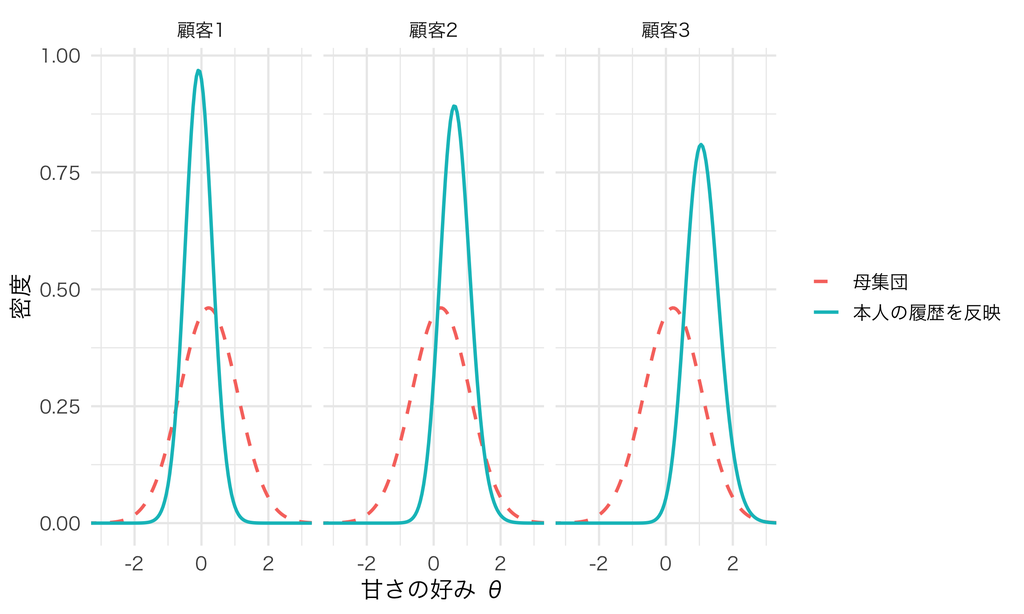

破線は共通の母集団密度、実線は本人の8回の履歴を取り込んだ事後密度。

```r
continuous_plot_c <- do.call(rbind, lapply(show_c, function(i) {
  data.frame(theta = rep(theta_nodes_c, 2), customer = paste0("顧客", i),
    density = c(dnorm(theta_nodes_c, mu_hat_c, tau_hat_c), post_eb_c[i, ] / theta_w_c),
    information = factor(rep(c("母集団", "本人の履歴を反映"), each = length(theta_nodes_c)),
                         levels = c("母集団", "本人の履歴を反映")))
}))
ggplot(continuous_plot_c, aes(theta, density, color = information, linetype = information)) +
  geom_line(linewidth = .9) + facet_wrap(~customer, nrow = 1) +
  scale_linetype_manual(values = c(2, 1)) + coord_cartesian(xlim = c(-3, 3)) +
  labs(x = "甘さの好み θ", y = "密度", color = NULL, linetype = NULL)
```

`post_eb_c` は、連続密度を格子点と積分の幅で近似した重みである。図ではその重みを積分の幅 `theta_w_c` で割り、密度として描いている。格子点の重みを、連続分布で一点に置かれた確率と取り違えないようにしよう。

有限タイプの式の $\sum_k$ が $\int$ に変わっても、「母集団の分布×本人の尤度を正規化する」という計算は同じだ。正規分布を仮定したのは母集団であり、本人の事後密度は一般に正規ではない。

**ノート連続分布でも個人別最尤と比べられる**

母集団の密度を使わず、$\widehat\theta_i^{\mathrm{NP}}\in\arg\max_\theta L(\theta;H_i)$ とする考え方は同じである。ただし、一人が毎回Bだけを選ぶような短い履歴では、$\theta\to+\infty$ とするほど尤度が上がり、有限の最尤推定値が存在しない場合がある。有限3タイプでは、あらかじめ候補値を限定したためこの問題は起こらなかった。連続分布の事前密度は、極端な係数が母集団でどれほどありそうかも計算に取り込む。推定対象のsupportと利用する情報を揃えて、比較の意味を考える必要がある。

**ヒント研究コラム：Train — 母集団分布から個人の係数へ**

Trainの教科書第11章は、random coefficient logitで母集団の係数分布を推定した後、その人の選択履歴を使って個人の係数分布を求める問題を扱う。釣り場選択の例では、キャンプ場を好む人も避ける人もいるという母集団の異質性と、特定の釣り人がどちらに近いかという問いを区別している。本講義の3つの重みは、その連続分布の更新を有限タイプで見える形にしたものだ。[Train (2009), Chapter 11](https://eml.berkeley.edu/books/choice2nd/Ch11_p259-281.pdf)

### 5.7 数値積分の確認

グリッドが狭すぎると端の外側を無視し、粗すぎると積分が不正確になる。まず、各人の事後重みについて、格子の外側2点にある合計が小さいか確認する。さらに係数の格子を121・241・481点に変え、範囲を $[-8,8]$ に広げた641点でもEMで推定し直す。端の重みが小さくても、それだけで精度が保証されるわけではないため、格子の範囲や細かさを変えた比較も必要である。

**事後分布の端と、積分の格子・範囲を確認する**

```r
edge_theta_eb_c <- max(rowSums(post_eb_c[, c(1:2, 240:241), drop = FALSE]))
knitr::kable(data.frame(quantity = "θの外側2点：全員の最大値", mass = edge_theta_eb_c),
             col.names = c("確認する場所", "事後重みの合計"), digits = 12)
```

| 確認する場所 | 事後重みの合計 |
| --- | --- |
| θの外側2点：全員の最大値 | 0.00000000032 |

**事後分布の端と、積分の格子・範囲を確認する**

```r
stopifnot(all(is.finite(post_eb_c)), max(abs(rowSums(post_eb_c) - 1)) < 1e-10,
          edge_theta_eb_c < .0001)
fit_with_nodes_c <- function(n_nodes, limit = 6) {
  nodes <- seq(-limit, limit, length.out = n_nodes)
  weights <- trap_weights_c(nodes)
  ell <- log_lik_c(dat_c, nodes)
  rowmax <- apply(ell, 1, max)
  lik <- exp(ell - rowmax)
  op <- fit_em_normal_c(nodes = nodes, node_w = weights, lik = lik, rowmax = rowmax)
  c(mu = op$mu, tau = op$tau)
}
quad_compare_c <- rbind(coarse = fit_with_nodes_c(121),
                        main = c(mu_hat_c, tau_hat_c), fine = fit_with_nodes_c(481),
                        wider = fit_with_nodes_c(641, limit = 8))
knitr::kable(data.frame(range = c("[-6, 6]", "[-6, 6]", "[-6, 6]", "[-8, 8]"),
                        nodes = c(121, 241, 481, 641), quad_compare_c), digits = 5,
             row.names = FALSE, col.names = c("θの積分範囲", "θの格子点数", "μのEM推定", "τのEM推定"))
```

| θの積分範囲 | θの格子点数 | μのEM推定 | τのEM推定 |
| --- | --- | --- | --- |
| [-6, 6] | 121 | 0.21362 | 0.86656 |
| [-6, 6] | 241 | 0.21362 | 0.86656 |
| [-6, 6] | 481 | 0.21362 | 0.86656 |
| [-8, 8] | 641 | 0.21362 | 0.86656 |

**事後分布の端と、積分の格子・範囲を確認する**

```r
stopifnot(max(abs(sweep(quad_compare_c, 2, quad_compare_c[2, ], "-"))) < .005)
```

この例の設定では、格子を細かくし、係数の積分範囲を広げても、結果は近い。これはここで試した範囲についての確認であり、別のモデルやデータでも同じ格子で十分だという保証ではない。

## 6. 今回の整理：母集団を知ることと、本人を知ること

この講義では、一人の好みは固定したまま、分析者が持つ情報を更新してきた。母集団の分布が分かっても、その人の好みが分かったわけではない。本人の履歴は、どの好みならその選択列が起こりやすいかという尤度を通じて、本人についての分布に取り込まれる。

| 段階 | 母集団について未知のもの | 個人の履歴の取り込み方 |
| --- | --- | --- |
| 既知の3タイプ分布 | なし | 既知の割合×本人の尤度を正規化 |
| 既知の3候補値 | 割合 $\pi$ | 推定した割合で経験ベイズ |
| 未知の3候補値 | 候補値と割合 | EMで推定し、その重みを個人の分布にする |
| 連続正規分布 | 平均 $\mu$ と標準偏差 $\tau$ | EMで推定した密度×本人の尤度を積分で正規化 |

**有限か連続か**は好みの母集団分布をどう表すかの選択である。どちらでも、まず母集団の分布を推定し、その推定分布と本人の履歴を組み合わせる経験ベイズの考え方が使える。

**識別**は、母集団の観測分布からタイプの値と割合を一意に決められるかという問いである。**推定**は、有限の標本からその未知の値を求める作業であり、**EM**はその最尤推定を計算する方法の一つである。母集団の分布が識別できても、短い履歴しかない本人のタイプが確定するわけではない。

また、人数 $N$ が増えることは主に母集団の分布を学ぶ助けになり、本人の履歴 $T_i$ が増えることは本人の好みを区別する助けになる。大人数のデータから $F$ が精密に分かっても、本人の履歴が短ければ、その人の事後分布には不確実性が残る。

### 自分の言葉で説明してみよう

1. 母集団に苦味好きが25%いると分かっていても、ある人の好みが分からないのはなぜか。
2. 尤度と事後確率は何が違うか。3タイプの更新式で分子と分母を説明できるか。
3. パネルの尤度では、なぜ選択機会について掛けてからタイプについて平均するのか。
4. EMのE-stepとM-stepでは、それぞれ何を固定して、何を更新するのか。EMが収束すれば識別できたと言えるか。
5. 正規分布モデルのMステップで、事後平均どうしのばらつきだけを使うと何が抜けるか。母集団が正規分布なら、個人の事後分布も正規分布になるか。
6. 2回分の全9通りの履歴確率が同じ二つの母集団を、3回目のどんな情報が区別するか。タイプの値が一致する場合や、割合が0の場合には、識別の証明のどこが成り立たなくなるか。

実験室で重みの変化を試す ／ 課題6 ／ 講義一覧に戻る

### 次回へのつながり

次回の第7回：データを意思決定に使うでは、誰に施策を届けるか、顧客との関係をどう評価するか、どのような新商品を作るかを考える。まず意思決定の目的から必要な量を定め、その量を知るためのデータとモデルを選ぶ。今回の好みの推定が役立つ場面と、施策のランダム化実験など別の情報が必要な場面を区別しよう。